**31th, October 2022**

# Data Scientist Udacity Nanodegree - Capstone Project: Starbucks Capstone Challenge

#### Author: Sebastian Heß

[figure not shown]

1. Introduction
1. Project Information by Udacity
2. Section 1: Project Definition
1. Project Overview
2. Project Statement
3. Metrics
3. Section 2: Exploratory Data Analysis
1. Data Exploration
1. Data Wrangling
1. Portfolio (offer)
2. Profile (demographic)
3. Transcript (transaction records)
4. Merge of the Data Frames
2. Data Visualization
1. Question 1: How is the distribution of the variable "age"?
2. Question 2: How is the distribution of the variable "gender"?
3. Question 3: How is the distribution of the variable "income"?
4. Question 4: How is the distribution of the variable "gender" correlated to the age clusters?
5. Question 5: How is the distribution of the variable "gender" correlated to the income clusters?
6. Question 6: How is the distribution of the variable "age" correlated to the offer types?
7. Question 7: How is the distribution of the variable "gender" correlated to the offer types?
8. Question 8: How is the distribution of the variable "gender" correlated to the events?
9. Question 9: How is the distribution of the variable "age" correlated to the events?
4. Section 3: Methodology
1. Data Preprocessing
1. Eliminating Outliers of variable "age"
2. Imputing Missing Values
3. *Dropping Missing Values (Discarded - Not used)*
4. Splitting the variable "channels" in categorical variables based on its values
5. Splitting the variable "event" in categorical variables based on its values
6. Splitting the variable "offer_type" in categorical variables based on its values
7. Splitting the variable "gender" in categorical variables based on its values
8. Splitting the variable "age" in categorical variables based on its values
9. Creating a new variable "row_count"
2. Implementation
1. Creating a machine learning model
2. Creating a function for a confusion matrix
3. Creating a data frame with metrics
4. Machine learning model inital setup
5. Model: NULL
6. Model A: Logistic Regression Classifier
7. Model B: Decision Trees Classifier
8. Model C: Naive Bayes Classifier
9. Model D: KNeighbors Classifier
3. Refinement
1. Metrics
2. Classification Threshold: Modifying the classification threshold
3. Classification Threshold: Visualization of the recall/precision correlation of "NaiveBase" and "KNeighbors" models
4. Classification Threshold: Visualization of the recall, precision/threshold correlation of the "KNeighbors" model
5. Classification Threshold: Adjusting "KNeigbhors" classifier with a threshold value of 0.95
5. Section 4: Results
1. Model Evaluation and Validation
2. Justification
6. Section 5: Conclusion
1. Reflection
2. Improvement
7. References

# 1. Introduction

Table of Content

## 1. A. Project Information provided by Udacity

Table of Content

### Introduction

This data set contains simulated data that mimics customer behavior on the Starbucks rewards mobile app. Once every few days, Starbucks sends out an offer to users of the mobile app. An offer can be merely an advertisement for a drink or an actual offer such as a discount or BOGO (buy one get one free). Some users might not receive any offer during certain weeks.

Not all users receive the same offer, and that is the challenge to solve with this data set.

Your task is to combine transaction, demographic and offer data to determine which demographic groups respond best to which offer type. This data set is a simplified version of the real Starbucks app because the underlying simulator only has one product whereas Starbucks actually sells dozens of products.

Every offer has a validity period before the offer expires. As an example, a BOGO offer might be valid for only 5 days. You'll see in the data set that informational offers have a validity period even though these ads are merely providing information about a product; for example, if an informational offer has 7 days of validity, you can assume the customer is feeling the influence of the offer for 7 days after receiving the advertisement.

You'll be given transactional data showing user purchases made on the app including the timestamp of purchase and the amount of money spent on a purchase. This transactional data also has a record for each offer that a user receives as well as a record for when a user actually views the offer. There are also records for when a user completes an offer.

Keep in mind as well that someone using the app might make a purchase through the app without having received an offer or seen an offer.

### Example

To give an example, a user could receive a discount offer buy 10 dollars get 2 off on Monday. The offer is valid for 10 days from receipt. If the customer accumulates at least 10 dollars in purchases during the validity period, the customer completes the offer.

However, there are a few things to watch out for in this data set. Customers do not opt into the offers that they receive; in other words, a user can receive an offer, never actually view the offer, and still complete the offer. For example, a user might receive the "buy 10 dollars get 2 dollars off offer", but the user never opens the offer during the 10 day validity period. The customer spends 15 dollars during those ten days. There will be an offer completion record in the data set; however, the customer was not influenced by the offer because the customer never viewed the offer.

### Cleaning

This makes data cleaning especially important and tricky.

You'll also want to take into account that some demographic groups will make purchases even if they don't receive an offer. From a business perspective, if a customer is going to make a 10 dollar purchase without an offer anyway, you wouldn't want to send a buy 10 dollars get 2 dollars off offer. You'll want to try to assess what a certain demographic group will buy when not receiving any offers.

### Final Advice

Because this is a capstone project, you are free to analyze the data any way you see fit. For example, you could build a machine learning model that predicts how much someone will spend based on demographics and offer type. Or you could build a model that predicts whether or not someone will respond to an offer. Or, you don't need to build a machine learning model at all. You could develop a set of heuristics that determine what offer you should send to each customer (i.e., 75 percent of women customers who were 35 years old responded to offer A vs 40 percent from the same demographic to offer B, so send offer A).

## Data Sets

The data is contained in three files:

- **portfolio.json** - containing offer ids and meta data about each offer (duration, type, etc.)
- **profile.json** - demographic data for each customer
- **transcript.json** - records for transactions, offers received, offers viewed, and offers completed

Here is the schema and explanation of each variable in the files:

**portfolio.json**

- id (string) - offer id
- offer_type (string) - type of offer ie BOGO, discount, informational
- difficulty (int) - minimum required spend to complete an offer
- reward (int) - reward given for completing an offer
- duration (int) - time for offer to be open, in days
- channels (list of strings)

**profile.json**

- age (int) - age of the customer
- became_member_on (int) - date when customer created an app account
- gender (str) - gender of the customer (note some entries contain 'O' for other rather than M or F)
- id (str) - customer id
- income (float) - customer's income

**transcript.json**

- event (str) - record description (ie transaction, offer received, offer viewed, etc.)
- person (str) - customer id
- time (int) - time in hours since start of test. The data begins at time t=0
- value - (dict of strings) - either an offer id or transaction amount depending on the record

**Note:** If you are using the workspace, you will need to go to the terminal and run the command `conda update pandas` before reading in the files. This is because the version of pandas in the workspace cannot read in the transcript.json file correctly, but the newest version of pandas can. You can access the termnal from the orange icon in the top left of this notebook.

You can see how to access the terminal and how the install works using the two images below. First you need to access the terminal:

[figure not shown]

Then you will want to run the above command:

[figure not shown]

Finally, when you enter back into the notebook (use the jupyter icon again), you should be able to run the below cell without any errors.

# 2. Section 1: Project Definition

Table of Content

## 2. A. Project Overview

Table of Content

This is the final project of my Udacity Data Scientist Nanodegree. I chose the Starbuck's Capstone Challenge project because I'm interested in the experience of studying user demographic purchasing behavior across different offer types to determine which demographics respond best to which offer type.

The data consists of simulated data that mimics customer behavior in the Starbucks Rewards mobile app. Starbuck regularly sends customers offers through the mobile app. The offers contain either advertising or various discount options.

Identifying the top responding demographics by offer type requires combining transactional, demographic, and offer data.

## 2. B. Problem Statement

Table of Content

For this project Starbucks and Udacity are providing 3 data sets:

1. **Protfolio (offer)** - Containing offer ids and meta data about each offer sent during a 30-day test period (duration, type, etc.)
2. **Profile (demographic)** - Containing demographic data of the rewards program for each customer.
3. **Transcript (transaction records)** - Containing event logs like records for transactions, offers received, offers viewed, and offers completed.

##### **Facts:**

- The users might not receive any offer in a specific time range.
- The users are receiving different kinds of offers.

##### **Tasks:**

1. Exploring the data by wrangling.
2. Data Analyse by Visualization of the data.
3. Preprocessing the data.
4. Implementation of the machine learning model.
5. Refinement of the machine learning model.
6. Evaluation of the machine learning model and justification of the results.
7. Reflection about the solution and potential improvements.

##### **Challenges:**

1. My main objective is to implement a logic that makes it possible to predict if a customer will complete an offer of the offer type *bogo*.

## 2. C. Metrics

Table of Content

The following metrics are chosen to evaluate the model's performance:

> - **Accuracy:** the proportion of the total number of predictions that are correct.  
>   (The total, how often the model predicts correctly "completers" and "Non-completers".)
> - **Precision:** the proportion of positive predictions that are actually correct.  
>   (When the model predicts complete: How often is correct?)
> - **Recall:** the proportion of positive observed values correctly predicted as such.  
>   (The proportion of actual completers that the model will correctly predict as such.)

# 3. Section 2: Exploratory Data Analysis

Table of Content

## 3. A. Data Exploration

Table of Content

#### Description of the data sets, including the features, data distributions, and descriptive statistics. Identification of any abnormalities or specific characteristics inherent in the data sets.

### Imported Libraries and Modules

> - **OS** a python module which priveds functions for interacting with the operating system OS.
> - **Numpy** a Python library for working with arrays.
> - **Pandas** a Python library for data manipulating and analysis.
> - **pandas.plotting** Helper function to convert DataFrame and Series to matplotlib.table.
> - **import math** math module has a set of methods and constants.
> - **import json** to work with JSON data.
> - **Matplotlib** a Python library for data visualizations.
> - **%matplotlib inline** a magic function for inline plotting of graphs.
> - **Seaborn** a Python library for data visuallization based on matplotlib.
> - **sns.set_style** to define the seaborn figure aesthetic as "darkgrid".
> - **sklearn.model_selection** a class of the sklearn module splitting the data in train and test data.
> - **sklearn.metrics** a class of the sklearn metrics to use with any continous response variable.
> - **sklearn preprocessing** a class of the sklearn module providing several common utility functions and transformer classes to change raw feature vectors into a representation that is more suitable for the downstream estimators.
> - **sklearn RobustScaler** a class of the sklearn module scaling features using statistics that are robust to outliers.
> - **sklearn LogisticRegression** a class of the sklearn module containing different functions for performing machine learning with linear models.
> - **sklearn DecisionTreeClassifier** a class of the sklearn module based on a decision tree classifier.
> - **sklearn GaussianNB** a class of the sklearn module based on Gaussian Naive Bayes (GaussianNB).
> - **sklearn KNeighborsClassifier** a class of the sklearn module based on a classifier implementing the k-nearest neighbors vote.

```python
# Importing Libraries
import os as os
import numpy as np
import pandas as pd
from pandas.plotting import table
import math
import json
import matplotlib.pyplot as plt
%matplotlib inline
import seaborn as sns
sns.set_style('darkgrid')

# ML tools: Import the ML libraries required
from sklearn.model_selection import train_test_split
from sklearn.metrics import accuracy_score, precision_score, recall_score, confusion_matrix, precision_recall_curve
from sklearn import preprocessing
from sklearn.preprocessing import RobustScaler
from sklearn.linear_model import LogisticRegression
from sklearn.tree import DecisionTreeClassifier
from sklearn.naive_bayes import GaussianNB
from sklearn.neighbors import KNeighborsClassifier
```

## 3. A. a. Data Wrangling

Table of Content

```python
# Reading in the json files
portfolio = pd.read_json('data/portfolio.json', orient='records', lines=True)
profile = pd.read_json('data/profile.json', orient='records', lines=True)
transcript = pd.read_json('data/transcript.json', orient='records', lines=True)
```

## Portfolio (offer) - General Properties of Fata Frame

Table of Content

#### Information: Offers sent during 30-day test period (10 offers x 6 fields)

> - reward: (numeric) money awarded for the amount spent
> - channels: (list) web, email, mobile, social
> - difficulty: (numeric) money required to be spent to receive reward
> - duration: (numeric) time for offer to be open, in days
> - offer_type: (string) bogo, discount, informational
> - id: (string/hash)

```python
# Checking the shape of the data frame
portfolio.shape
```

```
(10, 6)
```

**Conclusion:** The data frame consits of *6* columns and *10* rows.

```python
# Displaying data frame to get an idea of the data
portfolio.head()
```

|  | reward | channels | difficulty | duration | offer_type | id |
| --- | --- | --- | --- | --- | --- | --- |
| 0 | 10 | [email, mobile, social] | 10 | 7 | bogo | ae264e3637204a6fb9bb56bc8210ddfd |
| 1 | 10 | [web, email, mobile, social] | 10 | 5 | bogo | 4d5c57ea9a6940dd891ad53e9dbe8da0 |
| 2 | 0 | [web, email, mobile] | 0 | 4 | informational | 3f207df678b143eea3cee63160fa8bed |
| 3 | 5 | [web, email, mobile] | 5 | 7 | bogo | 9b98b8c7a33c4b65b9aebfe6a799e6d9 |
| 4 | 5 | [web, email] | 20 | 10 | discount | 0b1e1539f2cc45b7b9fa7c272da2e1d7 |

**Conclusion:**

1. Since the variable "offer_type" is relevant for this analysis its values will be investigated more detailed.
2. The variable "id" represents the **offer id**.
3. The variable "channels" will be split in categorical variables based on its values.

```python
# Checking a concise summary of the dataframe
portfolio.info()
```

```
<class 'pandas.core.frame.DataFrame'>
RangeIndex: 10 entries, 0 to 9
Data columns (total 6 columns):
 #   Column      Non-Null Count  Dtype
---  ------      --------------  -----
 0   reward      10 non-null     int64
 1   channels    10 non-null     object
 2   difficulty  10 non-null     int64
 3   duration    10 non-null     int64
 4   offer_type  10 non-null     object
 5   id          10 non-null     object
dtypes: int64(3), object(3)
memory usage: 608.0+ bytes
```

```python
# Checking the dtype of the dataframe
portfolio.dtypes
```

```
reward         int64
channels      object
difficulty     int64
duration       int64
offer_type    object
id            object
dtype: object
```

**Conclusion:** The data frame contains two different data types `object` and `int64`.

```python
# Checking the number of missing values
portfolio.isnull().sum()
```

```
reward        0
channels      0
difficulty    0
duration      0
offer_type    0
id            0
dtype: int64
```

**Conclusion:** The data frame does not contain any NaN values.

```python
# Checking for duplicate values
portfolio.columns.duplicated().any()
```

```
False
```

**Conclusion:** The data frame does **not** contain any duplicated values.

```python
# Checking the unique values of the data frame based in 'id'
portfolio['id'].nunique()
```

```
10
```

**Conclusion:** The variable "id" contains only unique values.

```python
# Checking and counting the "offer_type" values
portfolio.groupby('offer_type')['id'].count()
```

```
offer_type
bogo             4
discount         4
informational    2
Name: id, dtype: int64
```

**Conclusion:** The variable "offer_type" contains 3 values:

- `bogo` with a count of *4*,

  > Meaning: Buy one get one free.
- `discount` also with a count of *4* and

  > Meaning: Regular discount for an order.
- `informational` with a count of *2*.

  > Meaning: Special offers.

## Portfolio (offer) - Cleaning

**Tasks:**

1. Renaming the variable "id" in "offer_id".
2. Splitting the variable "channels" in categorical variables based on its values

```python
# Copying the data frame
portfolio_clean = portfolio.copy()
```

**Result:** The data frame is copied.

### 1. Renaming the variable "id"in "offer_id".

#### Code

```python
# Renaming the column "id"
portfolio_clean.rename(columns={'id':'offer_id'},inplace=True)
```

#### Test

```python
# # Displaying the new data frame to check the changes
portfolio_clean.head()
```

|  | reward | channels | difficulty | duration | offer_type | offer_id |
| --- | --- | --- | --- | --- | --- | --- |
| 0 | 10 | [email, mobile, social] | 10 | 7 | bogo | ae264e3637204a6fb9bb56bc8210ddfd |
| 1 | 10 | [web, email, mobile, social] | 10 | 5 | bogo | 4d5c57ea9a6940dd891ad53e9dbe8da0 |
| 2 | 0 | [web, email, mobile] | 0 | 4 | informational | 3f207df678b143eea3cee63160fa8bed |
| 3 | 5 | [web, email, mobile] | 5 | 7 | bogo | 9b98b8c7a33c4b65b9aebfe6a799e6d9 |
| 4 | 5 | [web, email] | 20 | 10 | discount | 0b1e1539f2cc45b7b9fa7c272da2e1d7 |

**Result:** The column "id" is renamed in "offer_id".

## Profile (demographic) - General Properties of Fata Frame

Table of Content

#### Information: Rewards program users (17000 users x 5 fields)

> - gender: (categorical) M, F, O, or null
> - age: (numeric) missing value encoded as 118
> - id: (string/hash)
> - became_member_on: (date) format YYYYMMDD
> - income: (numeric)

```python
# Checking the shape of the data frame
profile.shape
```

```
(17000, 5)
```

**Conclusion:** The data frame consits of *5* columns and *17,000* rows.

```python
# Displaying data frame to get an idea of the data
profile.head()
```

|  | gender | age | id | became_member_on | income |
| --- | --- | --- | --- | --- | --- |
| 0 | None | 118 | 68be06ca386d4c31939f3a4f0e3dd783 | 20170212 | NaN |
| 1 | F | 55 | 0610b486422d4921ae7d2bf64640c50b | 20170715 | 112000.0 |
| 2 | None | 118 | 38fe809add3b4fcf9315a9694bb96ff5 | 20180712 | NaN |
| 3 | F | 75 | 78afa995795e4d85b5d9ceeca43f5fef | 20170509 | 100000.0 |
| 4 | None | 118 | a03223e636434f42ac4c3df47e8bac43 | 20170804 | NaN |

**Conclusion:**

1. The following variables values will be investigated more detailed since they are relevant for this analysis:
   - "gender"
     - "None" values
   - "income"
     - "NaN" values
2. The variable "age" contains values which are unrealistically high.
   - `profile['age'][0]` → value = *118*
3. There is also a correlation between the three variables:

| index | gender | income | age |
| --- | --- | --- | --- |
| 0 | None | NaN | 118 |
| 2 | None | NaN | 118 |
| 4 | None | NaN | 118 |
| ... | ... | ... | ... |

1. The variable "id" represents the **customer id**.

```python
# Checking a concise summary of the dataframe
profile.info()
```

```
<class 'pandas.core.frame.DataFrame'>
RangeIndex: 17000 entries, 0 to 16999
Data columns (total 5 columns):
 #   Column            Non-Null Count  Dtype
---  ------            --------------  -----
 0   gender            14825 non-null  object
 1   age               17000 non-null  int64
 2   id                17000 non-null  object
 3   became_member_on  17000 non-null  int64
 4   income            14825 non-null  float64
dtypes: float64(1), int64(2), object(2)
memory usage: 664.2+ KB
```

```python
# Checking the dtype of the dataframe
profile.dtypes
```

```
gender               object
age                   int64
id                   object
became_member_on      int64
income              float64
dtype: object
```

**Conclusion:**

1. The data frame contains three different data types:
   - `object`
   - `int64`
   - `float64`
2. The variable "became_member_on" should be converted into a date format.  
   It is also possible that there is a correlation with the offers, which can be investigated.

```python
# Checking the number of missing values
profile.isnull().sum()
```

```
gender              2175
age                    0
id                     0
became_member_on       0
income              2175
dtype: int64
```

**Conclusion:**

1. The following variables of the data frame are containing NaN values:
   - "gender"
   - "income"
2. The amount of NaN values of both variables is equal. The sum is *2175*.

```python
# Function: Defining function to create a list of values existig in the variable (column).
def f_create_var_list(df, col_name):
    '''
    INPUT:
    df - Pandas data frame with dictionary to create new columns.
    col_name - List of values (strings) of the variable (columns).

    OUTPUT:
    var_list - New list of the following characteristics:
            1. Contains all values of a variable in a list.
    Description:
    Creates a list of values existig in a variable (column).
    '''
    var_list = list(dict.fromkeys(df[col_name]))


    return var_list
```

**Result:** A function is created to create a list of values existig in a variable (column).

```python
# Using the function: f_create_var_list
f_create_var_list(profile, 'gender')
```

```
[None, 'F', 'M', 'O']
```

**Conclusion:** The variable "gender" cointains the values:

- F → 'Female'
- M → 'Male'
- O → 'Other'
- NaN → 'None'

```python
# Checking for duplicate values
profile.columns.duplicated().any()
```

```
False
```

**Conclusion:** The data frame does not contain any duplicated values.

```python
# Showing the unique values of the data frame
profile['id'].nunique()
```

```
17000
```

**Conclusion:** The variable "id" contains only unique values (no NaN).

```python
# Checking and counting the "age" values
pro_118 = profile[profile['age'] == 118]
pro_118.head()
```

|  | gender | age | id | became_member_on | income |
| --- | --- | --- | --- | --- | --- |
| 0 | None | 118 | 68be06ca386d4c31939f3a4f0e3dd783 | 20170212 | NaN |
| 2 | None | 118 | 38fe809add3b4fcf9315a9694bb96ff5 | 20180712 | NaN |
| 4 | None | 118 | a03223e636434f42ac4c3df47e8bac43 | 20170804 | NaN |
| 6 | None | 118 | 8ec6ce2a7e7949b1bf142def7d0e0586 | 20170925 | NaN |
| 7 | None | 118 | 68617ca6246f4fbc85e91a2a49552598 | 20171002 | NaN |

```python
# Checking if there are any "F", "M" or "O" values in the variable "gender"
# while filtering varibale "age" equal to the value 118
pro_118_F = pro_118[pro_118['gender'] == 'F']['gender'].count()
pro_118_M = pro_118[pro_118['gender'] == 'M']['gender'].count()
pro_118_O = pro_118[pro_118['gender'] == 'O']['gender'].count()
pro_118_NaN = pd.isna(pro_118["gender"]).count()

print('Count of value "(F) Female" = {}'.format(pro_118_F))
print('Count of value "(M) Male" = {}'.format(pro_118_M))
print('Count of value "(O) Other" = {}'.format(pro_118_O))
print('Count of value "(None) NaN" = {}'.format(pro_118_NaN))
```

```
Count of value "(F) Female" = 0
Count of value "(M) Male" = 0
Count of value "(O) Other" = 0
Count of value "(None) NaN" = 2175
```

**Conclusion:**

1. The variable "age" filtered by the value of *118* shows that the variable "gender" does not include other values except of the "NaN" values.
2. The amount of "NaN" values *2175* is equal to the amount of "NaN" values of the variable "gender" and "income" within the "profile" data frame.

```python
# Calculating the descriptive statistics of the "age" values grouped by the variable "gender"
# (50 % is equal to the median)
profile.groupby('gender')['age'].describe()
```

| gender | count | mean | std | min | 25% | 50% | 75% | max |
| --- | --- | --- | --- | --- | --- | --- | --- | --- |
| F | 6129.0 | 57.544950 | 16.883315 | 18.0 | 48.0 | 58.0 | 69.0 | 101.0 |
| M | 8484.0 | 52.116690 | 17.413894 | 18.0 | 39.0 | 53.0 | 65.0 | 100.0 |
| O | 212.0 | 54.400943 | 16.244710 | 20.0 | 43.0 | 55.0 | 66.0 | 100.0 |

```python
# Checking and counting the missing values of varibale "gender"
profile['gender'].isnull().sum()
```

```
2175
```

**Conclusion:**

1. The variable "gender" contains the following values and counts of values:
   - "F - Female" → count = *6129*
   - "M - Male" → count = *8484*
   - "O - Other" → count = *212*
   - "None - NaN" → count = *2175*
1. The max value of the descriptive statistics displays that the highest age value of the "gender" values "F", "M" and "O" is below *118*.
   - "F - Female" → value = *101.0*
   - "M - Male" → value = *100.0*
   - "O - Other" → value = *100.0*

## Profile (demographic) - Cleaning

**Tasks:**

1. Renaming the variable "id"in "customer_id".
2. Converting the variable "became_member_on" into a date format.

```python
# Copying the data frame
profile_clean = profile.copy()
```

**Result:** The data frame is copied.

### Renaming the variable "id"in "customer_id".

#### Code

```python
# Renaming the column "id"
profile_clean.rename(columns={'id':'customer_id'},inplace=True)
```

#### Test

```python
# Displaying the new data frame to check the changes
profile_clean.head()
```

|  | gender | age | customer_id | became_member_on | income |
| --- | --- | --- | --- | --- | --- |
| 0 | None | 118 | 68be06ca386d4c31939f3a4f0e3dd783 | 20170212 | NaN |
| 1 | F | 55 | 0610b486422d4921ae7d2bf64640c50b | 20170715 | 112000.0 |
| 2 | None | 118 | 38fe809add3b4fcf9315a9694bb96ff5 | 20180712 | NaN |
| 3 | F | 75 | 78afa995795e4d85b5d9ceeca43f5fef | 20170509 | 100000.0 |
| 4 | None | 118 | a03223e636434f42ac4c3df47e8bac43 | 20170804 | NaN |

**Result:** The column "id" is renamed in "customer_id".

### Converting the variable "became_member_on" into a date format.

#### Code

```python
# Converting the dtype of the column.
profile_clean['became_member_on'] = pd.to_datetime(profile_clean['became_member_on'], format='%Y%m%d')
```

**Result:** The dvariables data type is changed.

#### Test

```python
# Displaying the new data frame to check the changes
profile_clean.head()
```

|  | gender | age | customer_id | became_member_on | income |
| --- | --- | --- | --- | --- | --- |
| 0 | None | 118 | 68be06ca386d4c31939f3a4f0e3dd783 | 2017-02-12 | NaN |
| 1 | F | 55 | 0610b486422d4921ae7d2bf64640c50b | 2017-07-15 | 112000.0 |
| 2 | None | 118 | 38fe809add3b4fcf9315a9694bb96ff5 | 2018-07-12 | NaN |
| 3 | F | 75 | 78afa995795e4d85b5d9ceeca43f5fef | 2017-05-09 | 100000.0 |
| 4 | None | 118 | a03223e636434f42ac4c3df47e8bac43 | 2017-08-04 | NaN |

**Result:** The variable "became_member_on" is converted into a date format.

```python
# Checking the shape of the data frame
profile_clean.shape
```

```
(17000, 5)
```

**Result:** The data frame consits of *5* columns and *17,000* rows.

## Transcript (transaction records) - General Properties of Fata Frame

Table of Content

> - person: (string/hash)
> - event: (string) offer received, offer viewed, transaction, offer completed
> - value: (dictionary) different values depending on event type
> - offer id: (string/hash) not associated with any "transaction"
> - amount: (numeric) money spent in "transaction"
> - reward: (numeric) money gained from "offer completed"
> - time: (numeric) hours after start of test

```python
# Checking the shape of the data frame
transcript.shape
```

```
(306534, 4)
```

**Conclusion:** The data frame consits of *4* columns and *306,534* rows.

```python
# Displaying data frame to get an idea of the data
transcript.head()
```

|  | person | event | value | time |
| --- | --- | --- | --- | --- |
| 0 | 78afa995795e4d85b5d9ceeca43f5fef | offer received | {'offer id': '9b98b8c7a33c4b65b9aebfe6a799e6d9'} | 0 |
| 1 | a03223e636434f42ac4c3df47e8bac43 | offer received | {'offer id': '0b1e1539f2cc45b7b9fa7c272da2e1d7'} | 0 |
| 2 | e2127556f4f64592b11af22de27a7932 | offer received | {'offer id': '2906b810c7d4411798c6938adc9daaa5'} | 0 |
| 3 | 8ec6ce2a7e7949b1bf142def7d0e0586 | offer received | {'offer id': 'fafdcd668e3743c1bb461111dcafc2a4'} | 0 |
| 4 | 68617ca6246f4fbc85e91a2a49552598 | offer received | {'offer id': '4d5c57ea9a6940dd891ad53e9dbe8da0'} | 0 |

**Conclusion:**

1. The following variables values will be investigated more detailed since they are relevant for this analysis:
   - "time"
     - "0" values
   - "event"
     - `string` values
2. The variable "person" represents the **customer id**.
3. The variable "value" includes a dictionary with the
   - key → **offer id**
   - value → **value of offer id**

Because it is possible that there are more keys existing, this variable will be checked in detail.

1. Based on the included **offer id** and **value of offer id** this data frame can be used to merge the previous two data frames.
2. The variable "value" should be converted into a column which only contains the **offer id**.

```python
# Checking a concise summary of the dataframe
transcript.info()
```

```
<class 'pandas.core.frame.DataFrame'>
RangeIndex: 306534 entries, 0 to 306533
Data columns (total 4 columns):
 #   Column  Non-Null Count   Dtype
---  ------  --------------   -----
 0   person  306534 non-null  object
 1   event   306534 non-null  object
 2   value   306534 non-null  object
 3   time    306534 non-null  int64
dtypes: int64(1), object(3)
memory usage: 9.4+ MB
```

```python
# Checking the dtype of the dataframe
transcript.dtypes
```

```
person    object
event     object
value     object
time       int64
dtype: object
```

**Conclusion:**

```python
# Checking the number of missing values
transcript.isnull().sum()
```

```
person    0
event     0
value     0
time      0
dtype: int64
```

**Conclusion:** The data frame does not contain any NaN values.

```python
# Checking for duplicate values
transcript.columns.duplicated().any()
```

```
False
```

**Conclusion:** The data frame does not contain any duplicated values.

```python
# Showing the unique values of the data frame
transcript['person'].nunique()
```

```
17000
```

**Conclusion:** The data frame variable "person" (customer id) contains only *17,000* unique values. That is few compared to the total quantity of *306,534*. But it is the same amount of customer id´s as in the data frame "profile" variable.

```python
# Checking and counting the amount of "person" values when "time" = 0
df_0_time  = transcript[transcript['time'] == 0]['person'].count()
print('Count of "person" values when "time" = 0: {}'.format(df_0_time))
```

```
Count of "person" values when "time" = 0: 15561
```

**Conclusion:** The data frame, filtered by the variable "time" = 0 contains 15,561 "person" values.

```python
# Checking the unique values of the variable "event"
list_event = transcript['event'].unique().tolist()
```

**Conclusion:** The data frame variable "event" contains the following values:

- *'offer received'*
- *'offer viewed'*
- *'transaction'*
- *'offer completed'*

```python
# Checking the keys and values of the variable "value" in a sample.
list_value = transcript['value']
list_value.sample(9)
```

```
111741    {'offer id': '9b98b8c7a33c4b65b9aebfe6a799e6d9'}
26540     {'offer id': 'ae264e3637204a6fb9bb56bc8210ddfd'}
223913    {'offer id': '9b98b8c7a33c4b65b9aebfe6a799e6d9'}
297349    {'offer id': '9b98b8c7a33c4b65b9aebfe6a799e6d9'}
16422     {'offer id': 'fafdcd668e3743c1bb461111dcafc2a4'}
200012                                    {'amount': 2.33}
178609                                   {'amount': 12.79}
92354                                     {'amount': 0.68}
88597                                    {'amount': 13.54}
Name: value, dtype: object
```

```python
# Function: Defining function to create a list of keys existig in a dictionary in a variable (column).
def f_create_dict_key_list(df, col_name):
    '''
    INPUT:
    df - Pandas data frame with dictionary to create new columns.
    col_name - Dictionary of keys (strings).

    OUTPUT:
    dict_keys - New list of the following characteristics:
            1. Contains all keys of an dictionary in a list.
    Description:
    Creates a list of keys existig in a dictionary in a variable (column).
    '''
    dict_keys = []
    for index, row in df.iterrows():
        for key in row[col_name]:
            if key in dict_keys:
                continue
            else:
                dict_keys.append(key)

    return dict_keys
```

**Result:** A function is created to create a list of keys existig in a dictionary in a variable (column).

```python
# Using the function: f_create_dict_key_list
f_create_dict_key_list(transcript, 'value')
```

```
['offer id', 'amount', 'offer_id', 'reward']
```

**Conclusion:** The variable "value" cointains more then one key and different values:

- key → 'offer id'
- key → 'offer_id'
- key → 'amount'
- key → 'reward'

## Transcript (transaction records) - Cleaning

**Tasks:**

1. Renaming the variable "person"in "customer_id".
2. Splitting the variable "event" in categorical variables based on its values.
3. Converting the variable "value" into one column each key.
4. Combining the 2 offer id variables including their values in 1 variable "offer_id".

```python
# Copying the data frame
transcript_clean = transcript.copy()
```

**Result:** The data frame is copied.

### Renaming the variable "person"in "customer_id".

#### Code

```python
# Renaming the column "id"
transcript_clean.rename(columns={'person':'customer_id'},inplace=True)
```

#### Test

```python
# Displaying the new data frame to check the changes
transcript_clean.head()
```

|  | customer_id | event | value | time |
| --- | --- | --- | --- | --- |
| 0 | 78afa995795e4d85b5d9ceeca43f5fef | offer received | {'offer id': '9b98b8c7a33c4b65b9aebfe6a799e6d9'} | 0 |
| 1 | a03223e636434f42ac4c3df47e8bac43 | offer received | {'offer id': '0b1e1539f2cc45b7b9fa7c272da2e1d7'} | 0 |
| 2 | e2127556f4f64592b11af22de27a7932 | offer received | {'offer id': '2906b810c7d4411798c6938adc9daaa5'} | 0 |
| 3 | 8ec6ce2a7e7949b1bf142def7d0e0586 | offer received | {'offer id': 'fafdcd668e3743c1bb461111dcafc2a4'} | 0 |
| 4 | 68617ca6246f4fbc85e91a2a49552598 | offer received | {'offer id': '4d5c57ea9a6940dd891ad53e9dbe8da0'} | 0 |

**Result:** The column "person" is renamed in "customer_id".

### Converting the variable "value" into one column each key.

#### Code

```python
# Function: Defining function to create the columns for each of the dictionary keys.
def f_create_dict_df(df, col_name):
    '''
    INPUT:
    df - Pandas data frame with dictionary to create new columns.
    col_name - Dictionary of keys (strings).

    OUTPUT:
    df - New dataframe of the following characteristics:
            1. Contains all keys as columns.
            2. Removes the original columns in cat_cols (all).
            3. Create column for each key in cat_cols dictionary.
            4. Prefix of the column name: Underscore (_) for separating.
    Description:
    Converts the dictionary keys of an variable into separate columns.
    '''
    df= pd.concat([df.drop(col_name, axis=1),
                   df[col_name].apply(pd.Series).add_prefix('_').add_prefix(col_name)], axis=1)

    return df
```

**Result:** A function is created to convert the dictionary keys of an variable into separate columns.

```python
# Using the function: f_create_dict_df
transcript_clean = f_create_dict_df(transcript_clean, 'value')
```

**Result:** The function is used on this data frame.

#### Test

```python
# Displaying the new data frame to check the changes
transcript_clean.head()
```

|  | customer_id | event | time | value_offer id | value_amount | value_offer_id | value_reward |
| --- | --- | --- | --- | --- | --- | --- | --- |
| 0 | 78afa995795e4d85b5d9ceeca43f5fef | offer received | 0 | 9b98b8c7a33c4b65b9aebfe6a799e6d9 | NaN | NaN | NaN |
| 1 | a03223e636434f42ac4c3df47e8bac43 | offer received | 0 | 0b1e1539f2cc45b7b9fa7c272da2e1d7 | NaN | NaN | NaN |
| 2 | e2127556f4f64592b11af22de27a7932 | offer received | 0 | 2906b810c7d4411798c6938adc9daaa5 | NaN | NaN | NaN |
| 3 | 8ec6ce2a7e7949b1bf142def7d0e0586 | offer received | 0 | fafdcd668e3743c1bb461111dcafc2a4 | NaN | NaN | NaN |
| 4 | 68617ca6246f4fbc85e91a2a49552598 | offer received | 0 | 4d5c57ea9a6940dd891ad53e9dbe8da0 | NaN | NaN | NaN |

```python
# Checking "value" data frame based on one "customer_id"
transcript_clean[transcript_clean['customer_id']== '0009655768c64bdeb2e877511632db8f'].head(10)
```

|  | customer_id | event | time | value_offer id | value_amount | value_offer_id | value_reward |
| --- | --- | --- | --- | --- | --- | --- | --- |
| 55972 | 0009655768c64bdeb2e877511632db8f | offer received | 168 | 5a8bc65990b245e5a138643cd4eb9837 | NaN | NaN | NaN |
| 77705 | 0009655768c64bdeb2e877511632db8f | offer viewed | 192 | 5a8bc65990b245e5a138643cd4eb9837 | NaN | NaN | NaN |
| 89291 | 0009655768c64bdeb2e877511632db8f | transaction | 228 | NaN | 22.16 | NaN | NaN |
| 113605 | 0009655768c64bdeb2e877511632db8f | offer received | 336 | 3f207df678b143eea3cee63160fa8bed | NaN | NaN | NaN |
| 139992 | 0009655768c64bdeb2e877511632db8f | offer viewed | 372 | 3f207df678b143eea3cee63160fa8bed | NaN | NaN | NaN |
| 153401 | 0009655768c64bdeb2e877511632db8f | offer received | 408 | f19421c1d4aa40978ebb69ca19b0e20d | NaN | NaN | NaN |
| 168412 | 0009655768c64bdeb2e877511632db8f | transaction | 414 | NaN | 8.57 | NaN | NaN |
| 168413 | 0009655768c64bdeb2e877511632db8f | offer completed | 414 | NaN | NaN | f19421c1d4aa40978ebb69ca19b0e20d | 5.0 |
| 187554 | 0009655768c64bdeb2e877511632db8f | offer viewed | 456 | f19421c1d4aa40978ebb69ca19b0e20d | NaN | NaN | NaN |
| 204340 | 0009655768c64bdeb2e877511632db8f | offer received | 504 | fafdcd668e3743c1bb461111dcafc2a4 | NaN | NaN | NaN |

```python
# Checking a concise summary of the dataframe
transcript_clean.info()
```

```
<class 'pandas.core.frame.DataFrame'>
RangeIndex: 306534 entries, 0 to 306533
Data columns (total 7 columns):
 #   Column          Non-Null Count   Dtype
---  ------          --------------   -----
 0   customer_id     306534 non-null  object
 1   event           306534 non-null  object
 2   time            306534 non-null  int64
 3   value_offer id  134002 non-null  object
 4   value_amount    138953 non-null  float64
 5   value_offer_id  33579 non-null   object
 6   value_reward    33579 non-null   float64
dtypes: float64(2), int64(1), object(4)
memory usage: 16.4+ MB
```

**Result:** After processing the function there are 2 variables (dictionary keys of column "value") existing in the data frame which will be combined in the next step:

- "value_offer id" (space)
- "value_offer_id" (underscore)

### Combining the 2 offer id variables including their values in 1 variable "offer_id".

#### Code

```python
# Function: Defining function to combine 2 variables in one column where "col_name1" is NaN and "col_name2" is not NaN.
def f_create_var_2to1_df(df, col_new, col_name1, col_name2):
    '''
    INPUT:
    df - Pandas data frame including the necessary columns.
    col_new - New variable name (combined column)
    col_name1 - First variable name.
    col_name2 - Second variable name.

    OUTPUT:
    df - New dataframe of the following characteristics:
            1. Checks if col_new (string) is already existing in col_name1 and col_name2
            2. Combines 2 variables into 1 variable.
            3. Removes the original columns in cat_name1 and cat_name2 (all).
    Description:
    Combines 2 variables in one column where "col_name1" is NaN and "col_name2" is not NaN.
    '''
    # Checking if col_new (string) is already existing in col_name1 and col_name2
    if col_new == col_name1:
        df.rename(columns={col_name1:col_new + '_1'},inplace=True) # Renaming the identical variable name
        col_name1 = col_new + '_1'
        pass
    elif col_new == col_name2:
        df.rename(columns={col_name2:col_new + '_2'},inplace=True) # Renaming the identical variable name
        col_name2 = col_new + '_2'
        pass
    else:
        pass

    # Combining the 2 variables into 1 varible
    df[col_new] = np.where(df[col_name1].isnull() & df[col_name2].notnull(), df[col_name2], df[col_name1])

    # Dropping not needed columns.
    df = df.drop([col_name1, col_name2], axis=1)

    return df
```

**Result:** A function is created to combine 2 variables in one column.

```python
# Using the function: f_create_var_2to1_df
transcript_clean = f_create_var_2to1_df(transcript_clean, 'offer_id', 'value_offer id', 'value_offer_id')
```

**Result:** The function is used on this data frame.

#### Test

```python
# Displaying the new data frame to check the changes
transcript_clean.head()
```

|  | customer_id | event | time | value_amount | value_reward | offer_id |
| --- | --- | --- | --- | --- | --- | --- |
| 0 | 78afa995795e4d85b5d9ceeca43f5fef | offer received | 0 | NaN | NaN | 9b98b8c7a33c4b65b9aebfe6a799e6d9 |
| 1 | a03223e636434f42ac4c3df47e8bac43 | offer received | 0 | NaN | NaN | 0b1e1539f2cc45b7b9fa7c272da2e1d7 |
| 2 | e2127556f4f64592b11af22de27a7932 | offer received | 0 | NaN | NaN | 2906b810c7d4411798c6938adc9daaa5 |
| 3 | 8ec6ce2a7e7949b1bf142def7d0e0586 | offer received | 0 | NaN | NaN | fafdcd668e3743c1bb461111dcafc2a4 |
| 4 | 68617ca6246f4fbc85e91a2a49552598 | offer received | 0 | NaN | NaN | 4d5c57ea9a6940dd891ad53e9dbe8da0 |

**Result:**

- The keys of the variable "value" are converted into separate columns.
- The 2 offer id variables including their values are combined into 1 variable "offer_id".

```python
# Checking a concise summary of the dataframe
transcript_clean.info()
```

```
<class 'pandas.core.frame.DataFrame'>
RangeIndex: 306534 entries, 0 to 306533
Data columns (total 6 columns):
 #   Column        Non-Null Count   Dtype
---  ------        --------------   -----
 0   customer_id   306534 non-null  object
 1   event         306534 non-null  object
 2   time          306534 non-null  int64
 3   value_amount  138953 non-null  float64
 4   value_reward  33579 non-null   float64
 5   offer_id      167581 non-null  object
dtypes: float64(2), int64(1), object(3)
memory usage: 14.0+ MB
```

**Result:**

1. The new variable "offer_id" contains all values from the previous 2 offer id variables.
2. The following variables are containing a lot of NaN values:
   - "value_amount"
   - "value_reward"
   - "offer_id"

```python
# Checking the shape of the data frame
transcript_clean.shape
```

```
(306534, 6)
```

**Result:** The data frame consits of *6* columns and *306,534* rows.

## Merge of the Data Frames

Table of Content

### Merge of "transcript_clean" and "portfolio_clean"

```python
# Checking the shape of the data frame
transcript_clean.shape
```

```
(306534, 6)
```

```python
# Checking the shape of the data frame
portfolio_clean.shape
```

```
(10, 6)
```

```python
# Merging the data frame "transcript_clean" with the data frame "portfolio_clean"
df_merge_1 = transcript_clean.merge(portfolio_clean, on='offer_id', how='left')
df_merge_1.head()
```

|  | customer_id | event | time | value_amount | value_reward | offer_id | reward | channels | difficulty | duration | offer_type |
| --- | --- | --- | --- | --- | --- | --- | --- | --- | --- | --- | --- |
| 0 | 78afa995795e4d85b5d9ceeca43f5fef | offer received | 0 | NaN | NaN | 9b98b8c7a33c4b65b9aebfe6a799e6d9 | 5.0 | [web, email, mobile] | 5.0 | 7.0 | bogo |
| 1 | a03223e636434f42ac4c3df47e8bac43 | offer received | 0 | NaN | NaN | 0b1e1539f2cc45b7b9fa7c272da2e1d7 | 5.0 | [web, email] | 20.0 | 10.0 | discount |
| 2 | e2127556f4f64592b11af22de27a7932 | offer received | 0 | NaN | NaN | 2906b810c7d4411798c6938adc9daaa5 | 2.0 | [web, email, mobile] | 10.0 | 7.0 | discount |
| 3 | 8ec6ce2a7e7949b1bf142def7d0e0586 | offer received | 0 | NaN | NaN | fafdcd668e3743c1bb461111dcafc2a4 | 2.0 | [web, email, mobile, social] | 10.0 | 10.0 | discount |
| 4 | 68617ca6246f4fbc85e91a2a49552598 | offer received | 0 | NaN | NaN | 4d5c57ea9a6940dd891ad53e9dbe8da0 | 10.0 | [web, email, mobile, social] | 10.0 | 5.0 | bogo |

```python
# Checking the shape of the data frame
df_merge_1.shape
```

```
(306534, 11)
```

```python
# Checking a concise summary of the dataframe
df_merge_1.info()
```

```
<class 'pandas.core.frame.DataFrame'>
Int64Index: 306534 entries, 0 to 306533
Data columns (total 11 columns):
 #   Column        Non-Null Count   Dtype
---  ------        --------------   -----
 0   customer_id   306534 non-null  object
 1   event         306534 non-null  object
 2   time          306534 non-null  int64
 3   value_amount  138953 non-null  float64
 4   value_reward  33579 non-null   float64
 5   offer_id      167581 non-null  object
 6   reward        167581 non-null  float64
 7   channels      167581 non-null  object
 8   difficulty    167581 non-null  float64
 9   duration      167581 non-null  float64
 10  offer_type    167581 non-null  object
dtypes: float64(5), int64(1), object(5)
memory usage: 28.1+ MB
```

```python
# Checking the values of the variables "value_reward" and "reward".
df_merge_1[['value_reward', 'reward']].sample(9)
```

|  | value_reward | reward |
| --- | --- | --- |
| 92365 | NaN | 10.0 |
| 219925 | NaN | NaN |
| 277663 | NaN | 10.0 |
| 219655 | NaN | 2.0 |
| 32838 | NaN | NaN |
| 224467 | NaN | NaN |
| 26597 | NaN | NaN |
| 124836 | 2.0 | 2.0 |
| 175984 | NaN | NaN |

**Conclusion:** After the merge of the 2 data frames there are 2 variables (columns) which are probaply identical and should be combined into 1 variable:

- "value_reward"
- "reward"

## Merge of the Data Frames - Cleaning

**Tasks:**

1. Combining the 2 reward variables including their values in 1 variable "reward".

```python
# Copying the data frame
df_merge_1_clean = df_merge_1.copy()
```

**Result:** The data frame is copied.

### Combining the 2 reward variables including their values in 1 variable "reward".

#### Code

```python
# Checking a concise summary of the dataframe
df_merge_1_clean.info()
```

```
<class 'pandas.core.frame.DataFrame'>
Int64Index: 306534 entries, 0 to 306533
Data columns (total 11 columns):
 #   Column        Non-Null Count   Dtype
---  ------        --------------   -----
 0   customer_id   306534 non-null  object
 1   event         306534 non-null  object
 2   time          306534 non-null  int64
 3   value_amount  138953 non-null  float64
 4   value_reward  33579 non-null   float64
 5   offer_id      167581 non-null  object
 6   reward        167581 non-null  float64
 7   channels      167581 non-null  object
 8   difficulty    167581 non-null  float64
 9   duration      167581 non-null  float64
 10  offer_type    167581 non-null  object
dtypes: float64(5), int64(1), object(5)
memory usage: 28.1+ MB
```

```python
# Checking the values of the variables "value_reward" and "reward".
df_merge_1_clean[['value_reward', 'reward']].sample(9)
```

|  | value_reward | reward |
| --- | --- | --- |
| 43143 | NaN | NaN |
| 254956 | NaN | 10.0 |
| 127279 | 2.0 | 2.0 |
| 143340 | 5.0 | 5.0 |
| 161676 | NaN | 2.0 |
| 104340 | NaN | NaN |
| 144858 | NaN | NaN |
| 297128 | NaN | 0.0 |
| 111891 | NaN | 3.0 |

```python
# Checking the values of the variables "value_reward" and "reward".
df_reward = df_merge_1_clean[df_merge_1_clean['value_reward'].notna()]
df_reward[['value_reward', 'reward']].head()
```

|  | value_reward | reward |
| --- | --- | --- |
| 12658 | 2.0 | 2.0 |
| 12672 | 2.0 | 2.0 |
| 12679 | 5.0 | 5.0 |
| 12692 | 10.0 | 10.0 |
| 12697 | 10.0 | 10.0 |

```python
# Comparing if the variables "value_reward" and "reward" are identical
df_reward = pd.DataFrame(df_reward)
df_reward_1 = df_reward['reward']
df_reward_2 = df_reward['value_reward']
print((df_reward_1 == df_reward_2).all())
```

```
True
```

```python
# Checking a concise summary of the dataframe
df_reward.info()
```

```
<class 'pandas.core.frame.DataFrame'>
Int64Index: 33579 entries, 12658 to 306527
Data columns (total 11 columns):
 #   Column        Non-Null Count  Dtype
---  ------        --------------  -----
 0   customer_id   33579 non-null  object
 1   event         33579 non-null  object
 2   time          33579 non-null  int64
 3   value_amount  0 non-null      float64
 4   value_reward  33579 non-null  float64
 5   offer_id      33579 non-null  object
 6   reward        33579 non-null  float64
 7   channels      33579 non-null  object
 8   difficulty    33579 non-null  float64
 9   duration      33579 non-null  float64
 10  offer_type    33579 non-null  object
dtypes: float64(5), int64(1), object(5)
memory usage: 3.1+ MB
```

```python
# Checking existance of NaN values in data frame
df_merge_1_clean['value_reward'].isnull().any()
```

```
True
```

```python
# Checking existance of NaN values in data frame
df_merge_1_clean['reward'].notnull().any()
```

```
True
```

**Result:** Each value of the variable "value_reward" has an identical value in variable "reward". The variables can be combined into one variable without loosing any data.

```python
# Using the function: f_create_var_2to1_df
df_merge_1_clean = f_create_var_2to1_df(df_merge_1_clean, 'reward', 'value_reward', 'reward')
```

**Result:** The function is used on this data frame.

#### Test

```python
# Checking a concise summary of the dataframe
df_merge_1_clean.info()
```

```
<class 'pandas.core.frame.DataFrame'>
Int64Index: 306534 entries, 0 to 306533
Data columns (total 10 columns):
 #   Column        Non-Null Count   Dtype
---  ------        --------------   -----
 0   customer_id   306534 non-null  object
 1   event         306534 non-null  object
 2   time          306534 non-null  int64
 3   value_amount  138953 non-null  float64
 4   offer_id      167581 non-null  object
 5   channels      167581 non-null  object
 6   difficulty    167581 non-null  float64
 7   duration      167581 non-null  float64
 8   offer_type    167581 non-null  object
 9   reward        167581 non-null  float64
dtypes: float64(4), int64(1), object(5)
memory usage: 25.7+ MB
```

```python
# Displaying the new data frame to check the changes
df_merge_1_clean.head()
```

|  | customer_id | event | time | value_amount | offer_id | channels | difficulty | duration | offer_type | reward |
| --- | --- | --- | --- | --- | --- | --- | --- | --- | --- | --- |
| 0 | 78afa995795e4d85b5d9ceeca43f5fef | offer received | 0 | NaN | 9b98b8c7a33c4b65b9aebfe6a799e6d9 | [web, email, mobile] | 5.0 | 7.0 | bogo | 5.0 |
| 1 | a03223e636434f42ac4c3df47e8bac43 | offer received | 0 | NaN | 0b1e1539f2cc45b7b9fa7c272da2e1d7 | [web, email] | 20.0 | 10.0 | discount | 5.0 |
| 2 | e2127556f4f64592b11af22de27a7932 | offer received | 0 | NaN | 2906b810c7d4411798c6938adc9daaa5 | [web, email, mobile] | 10.0 | 7.0 | discount | 2.0 |
| 3 | 8ec6ce2a7e7949b1bf142def7d0e0586 | offer received | 0 | NaN | fafdcd668e3743c1bb461111dcafc2a4 | [web, email, mobile, social] | 10.0 | 10.0 | discount | 2.0 |
| 4 | 68617ca6246f4fbc85e91a2a49552598 | offer received | 0 | NaN | 4d5c57ea9a6940dd891ad53e9dbe8da0 | [web, email, mobile, social] | 10.0 | 5.0 | bogo | 10.0 |

```python
# Checking the shape of the data frame
df_merge_1_clean.shape
```

```
(306534, 10)
```

**Result:** The new variable "reward" contains all values from the previous 2 reward variables.

### Merge of "df_merge_clean" and "profile_clean"

```python
# Checking the shape of the data frame
df_merge_1_clean.shape
```

```
(306534, 10)
```

```python
# Checking the shape of the data frame
profile_clean.shape
```

```
(17000, 5)
```

```python
# Merging the data frame "transcript_clean" with the data frame "portfolio_clean"
df_merge_final = df_merge_1_clean.merge(profile_clean, on='customer_id', how='left')
df_merge_final.head()
```

|  | customer_id | event | time | value_amount | offer_id | channels | difficulty | duration | offer_type | reward | gender | age | became_member_on | income |
| --- | --- | --- | --- | --- | --- | --- | --- | --- | --- | --- | --- | --- | --- | --- |
| 0 | 78afa995795e4d85b5d9ceeca43f5fef | offer received | 0 | NaN | 9b98b8c7a33c4b65b9aebfe6a799e6d9 | [web, email, mobile] | 5.0 | 7.0 | bogo | 5.0 | F | 75 | 2017-05-09 | 100000.0 |
| 1 | a03223e636434f42ac4c3df47e8bac43 | offer received | 0 | NaN | 0b1e1539f2cc45b7b9fa7c272da2e1d7 | [web, email] | 20.0 | 10.0 | discount | 5.0 | None | 118 | 2017-08-04 | NaN |
| 2 | e2127556f4f64592b11af22de27a7932 | offer received | 0 | NaN | 2906b810c7d4411798c6938adc9daaa5 | [web, email, mobile] | 10.0 | 7.0 | discount | 2.0 | M | 68 | 2018-04-26 | 70000.0 |
| 3 | 8ec6ce2a7e7949b1bf142def7d0e0586 | offer received | 0 | NaN | fafdcd668e3743c1bb461111dcafc2a4 | [web, email, mobile, social] | 10.0 | 10.0 | discount | 2.0 | None | 118 | 2017-09-25 | NaN |
| 4 | 68617ca6246f4fbc85e91a2a49552598 | offer received | 0 | NaN | 4d5c57ea9a6940dd891ad53e9dbe8da0 | [web, email, mobile, social] | 10.0 | 5.0 | bogo | 10.0 | None | 118 | 2017-10-02 | NaN |

```python
# Checking the shape of the data frame
df_merge_final.shape
```

```
(306534, 14)
```

```python
# Checking a concise summary of the dataframe
df_merge_final.info()
```

```
<class 'pandas.core.frame.DataFrame'>
Int64Index: 306534 entries, 0 to 306533
Data columns (total 14 columns):
 #   Column            Non-Null Count   Dtype
---  ------            --------------   -----
 0   customer_id       306534 non-null  object
 1   event             306534 non-null  object
 2   time              306534 non-null  int64
 3   value_amount      138953 non-null  float64
 4   offer_id          167581 non-null  object
 5   channels          167581 non-null  object
 6   difficulty        167581 non-null  float64
 7   duration          167581 non-null  float64
 8   offer_type        167581 non-null  object
 9   reward            167581 non-null  float64
 10  gender            272762 non-null  object
 11  age               306534 non-null  int64
 12  became_member_on  306534 non-null  datetime64[ns]
 13  income            272762 non-null  float64
dtypes: datetime64[ns](1), float64(5), int64(2), object(6)
memory usage: 35.1+ MB
```

**Conclusion:**

```python
# Checking for duplicate values
df_merge_final.columns.duplicated().any()
```

```
False
```

**Conclusion:** The data frame does not contain any duplicated values.

```python
# Copying the data frame
df_final = df_merge_final.copy()
```

**Result:** The data frame is copied.

```python
# Saving data final data frame to .csv
df_final.to_csv('data/data.csv', index=False)
```

**Result:** The data frame is saved as .csv.

### Assessing Summary

> 1. The data frame consits of *14* columns and *306,534* rows.
> 2. The data frame contains NaN values.
> 3. The data frame contains missing values.
> 4. The data frame does NOT contain duplicate values.
> 5. The data frame contains data types which need to be changed.
> 6. Some values of the data frame have to be imputed.
> 7. After the data visualization part the data has to be processed further to prepae the data frame for the machine learning part.

## 3. B. Data Visualization

Table of Content

#### Data visualization based on the data exploration in the previous step.

Question 1: How is the Distribution of the variable "age"?

Question 2: How is the Distribution of the variable "gender"?

Question 3: How is the Distribution of the variable "income"?

Question 4: How is the Distribution of the variable "gender" correlated to the age clusters?

Question 5: How is the Distribution of the variable "gender" correlated to the income clusters?

Question 6: How is the Distribution of the variable "age" correlated to the offer types?

Question 7: How is the Distribution of the variable "gender" correlated to the offer types?

Question 8: How is the Distribution of the variable "gender" correlated to the events?

Question 9: How is the Distribution of the variable "age" correlated to the events?

```python
# Loading the final saved data frame
df_datav = df_final.copy()
#df_datav = pd.read_csv('data/data.csv', dtype=str, engine='python')
```

```python
# Function: Python Function that defines the size, the dots per inches, the facecolor of the axes,
# the figure patch edgecolor and the color of the color of the background of the plots and returns it.

def f_fig_axes():
    '''
    INPUT:
    None

    OUTPUT:
    Layout for plots - plt (Matplotlib), sns (seaborn)

    Description:
    Defines the size, the dots per inches, the facecolor of the axes, the figure patch edgecolor
    and the color of the color of the background of the plots and returns it.
    '''
    plt.subplots(figsize=(15, 5), dpi=80, facecolor='w', edgecolor='k')
    sns.set_style('darkgrid')
    print()
```

**Result:** A function is created that defines the size, the dots per inches, the facecolor of the axes, the figure patch edgecolor and the color of the color of the background of the plots and returns it.

```python
# Displaying the new data frame to check the changes
df_datav.head()
```

|  | customer_id | event | time | value_amount | offer_id | channels | difficulty | duration | offer_type | reward | gender | age | became_member_on | income |
| --- | --- | --- | --- | --- | --- | --- | --- | --- | --- | --- | --- | --- | --- | --- |
| 0 | 78afa995795e4d85b5d9ceeca43f5fef | offer received | 0 | NaN | 9b98b8c7a33c4b65b9aebfe6a799e6d9 | [web, email, mobile] | 5.0 | 7.0 | bogo | 5.0 | F | 75 | 2017-05-09 | 100000.0 |
| 1 | a03223e636434f42ac4c3df47e8bac43 | offer received | 0 | NaN | 0b1e1539f2cc45b7b9fa7c272da2e1d7 | [web, email] | 20.0 | 10.0 | discount | 5.0 | None | 118 | 2017-08-04 | NaN |
| 2 | e2127556f4f64592b11af22de27a7932 | offer received | 0 | NaN | 2906b810c7d4411798c6938adc9daaa5 | [web, email, mobile] | 10.0 | 7.0 | discount | 2.0 | M | 68 | 2018-04-26 | 70000.0 |
| 3 | 8ec6ce2a7e7949b1bf142def7d0e0586 | offer received | 0 | NaN | fafdcd668e3743c1bb461111dcafc2a4 | [web, email, mobile, social] | 10.0 | 10.0 | discount | 2.0 | None | 118 | 2017-09-25 | NaN |
| 4 | 68617ca6246f4fbc85e91a2a49552598 | offer received | 0 | NaN | 4d5c57ea9a6940dd891ad53e9dbe8da0 | [web, email, mobile, social] | 10.0 | 5.0 | bogo | 10.0 | None | 118 | 2017-10-02 | NaN |

## Question 1: How is the distribution of the variable "age"?

Table of Content

```python
# Calculating the descriptive statistics of the "age" values
# (50 % is equal to the median)
df_data_q1 = df_datav.copy() # Copying the orignal data frame
df_data_q1 = df_data_q1['age']
df_data_q1.describe()
```

```
count    306534.000000
mean         60.909367
std          26.032030
min          18.000000
25%          43.000000
50%          57.000000
75%          72.000000
max         118.000000
Name: age, dtype: float64
```

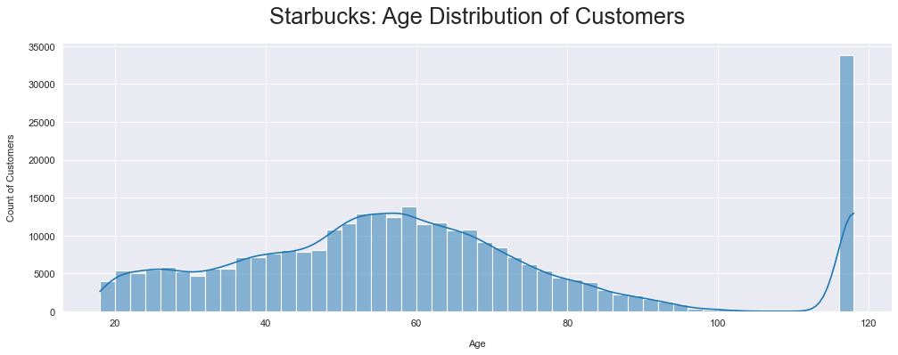

```python
# Calling the function"f_fig_axes()"
f_fig_axes()

# Plotting the age distribution.
sns.histplot(df_data_q1, bins=50, kde=True)

# Defining the title and the lables
plt.title('Starbucks: Age Distribution of Customers', fontsize=23, y=1.05)
plt.xlabel('Age', labelpad=12)
plt.ylabel('Count of Customers', labelpad=12)

# Saving the plot as a picture
plt.savefig('pics/plot_q1_age_hist.png', dpi=300, bbox_inches = "tight");
```

**Conclusion:**

## Question 2: How is the distribution of the variable "gender"?

Table of Content

```python
# Counting the amount of values and defining new data frame.
df_data_q2 = df_datav.copy() # Copying the orignal data frame
df_data_q2 = df_data_q2.astype(str).groupby('gender').agg({'customer_id':'count'})
df_data_q2
```

| gender | customer_id |
| --- | --- |
| F | 113101 |
| M | 155690 |
| None | 33772 |
| O | 3971 |

```python
# Checking the number of missing values of the variable "gender"
df_datav['gender'].isnull().sum()
```

```
33772
```

**Check:**

```python
# Defining the variable for the plot.
df_data_q2['gen_perc'] = (df_data_q2['customer_id']/df_data_q2['customer_id'].sum())*100
df_data_q2 = df_data_q2['gen_perc']
df_data_q2.head()
```

```
gender
F       36.896723
M       50.790451
None    11.017375
O        1.295452
Name: gen_perc, dtype: float64
```

[figure not shown]

```python
# Plotting the immediate booking possibility of apartments.

# Calling the function"f_fig_axes()"
f_fig_axes() # Python Function

# Defining the plot variables.
plot_labels = ('Female', 'Male', 'Other', 'NaN')
plot_base_color = ['skyblue', 'cornflowerblue', 'lightsteelblue', 'lightcoral']
plot_explode = (0.05, 0.05, 0.2, 0.2)  # Exploding the 4 slices (gapping)

# Defining the plot.
plt.pie(df_data_q2, explode=plot_explode, labels=plot_labels, autopct='%1.1f%%', shadow=True,
        startangle=90, colors=plot_base_color, textprops=dict(color="darkblue"))
plt.axis('equal')  # Ensuring that pie is drawn as a circle.

# Defining the title
plt.title('How is the Distribution of Genders compared to the total data quantity?', fontsize=18, y=1.03)

# Saving as a picture
plt.savefig('pics/plot_g2_gender_pie.png', dpi=300);
```

**Conclusion:**

## Question 3: How is the distribution of the variable "income"?

Table of Content

```python
# Calculating the descriptive statistics of the "income" values
# (50 % is equal to the median)
df_data_q3 = df_datav.copy() # Copying the orignal data frame
df_data_q3 = df_datav['income']
df_data_q3.describe()
```

```
count    272762.000000
mean      64337.000755
std       21243.762941
min       30000.000000
25%       48000.000000
50%       62000.000000
75%       78000.000000
max      120000.000000
Name: income, dtype: float64
```

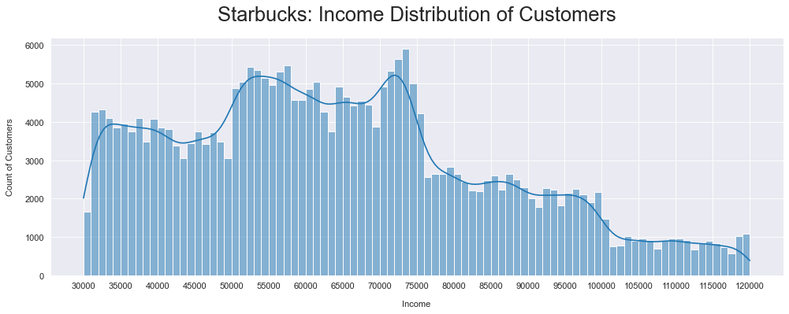

```python
# Calling the function"f_fig_axes()"
f_fig_axes()

# Plotting the age distribution.
sns.histplot(df_data_q3, bins=90, kde=True)

# Defining the title, the lables and the ticks
plt.title('Starbucks: Income Distribution of Customers', fontsize=23, y=1.05)
plt.xlabel('Income', labelpad=12)
plt.ylabel('Count of Customers', labelpad=12)
plt.xticks([30000, 35000, 40000, 45000, 50000, 55000, 60000, 65000, 70000, 75000, 80000, 85000, 90000,
            95000,100000, 105000, 110000, 115000, 120000])

# Saving the plot as a picture
plt.savefig('pics/plot_q3_income_hist.png', dpi=300, bbox_inches = "tight");
```

**Conclusion:**

1. **Distribution:** The distribution of the variable "income" is *right-skewed* (positive skewness).
2. **Cluster:** There are *4* income clusters existing:

   > **Cluster 1**: In a range between *30,000* and *50,000* USD.  
   > **Cluster 2**: In a range between *50,000* and *75,000* USD.  
   > **Cluster 3**: In a range between *75,000* and *100,000* USD.  
   > **Cluster 4**: In a range between *100,000* and *120,000* USD.

## Question 4: How is the distribution of the variable "gender" correlated to the age clusters?

Table of Content

```python
# Creating clusters for the age
df_data_q4 = df_datav.copy() # Copying the orignal data frame
df_data_q4['age_cluster'] = pd.cut(df_datav['age'], bins=[15, 24, 64, 120], labels=['Youth', 'Adults', 'Seniors'])

df_data_q4['age_cluster'].head()
```

```
0    Seniors
1    Seniors
2    Seniors
3    Seniors
4    Seniors
Name: age_cluster, dtype: category
Categories (3, object): ['Youth' < 'Adults' < 'Seniors']
```

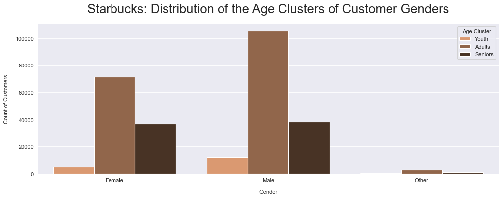

```python
# Calling the function"f_fig_axes()"
f_fig_axes()

# Plotting income cluster of customer genders.
plot_q4 = sns.countplot(data=df_data_q4, x='gender', hue='age_cluster', palette='copper_r')

# Defining the title, the lables and the ticks
plt.title('Starbucks: Distribution of the Age Clusters of Customer Genders', fontsize=23, y=1.05)
plt.xlabel('Gender', labelpad=12)
plt.xlabels = ['Female', 'Male', 'Other'] # Renaming the x axis values
plot_q4.set_xticklabels(plt.xlabels)
plt.ylabel('Count of Customers', labelpad=12)

# Defining legend
plt.legend(title='Age Cluster', loc='upper right')

# Saving the plot as a picture
plt.savefig('pics/plot_q4_gender_age_cluster.png', dpi=300, bbox_inches = "tight");
```

**Conclusion:**

1. **Major Customer Group:** The distribution of the age clusters of customer genders depicts that adult males are the major customer group existing in the data.
2. **Second Biggest Customer Group:** Adult females are the second biggest customer group existing in the data.
3. **Third Biggest Customer Group:** The third biggest customer group existing in the data are senior males and females.

## Question 5: How is the distribution of the variable "gender" correlated to the income clusters?

Table of Content

```python
# Creating clusters for the income
df_data_q5 = df_datav.copy() # Copying the orignal data frame
df_data_q5['income_cluster'] = pd.cut(df_datav['income'], bins=[30000, 50000, 75000, 100000, 120000],
                                       labels=['low', 'average', 'high', 'very_high'])

df_data_q5['income_cluster'].head()
```

```
0       high
1        NaN
2    average
3        NaN
4        NaN
Name: income_cluster, dtype: category
Categories (4, object): ['low' < 'average' < 'high' < 'very_high']
```

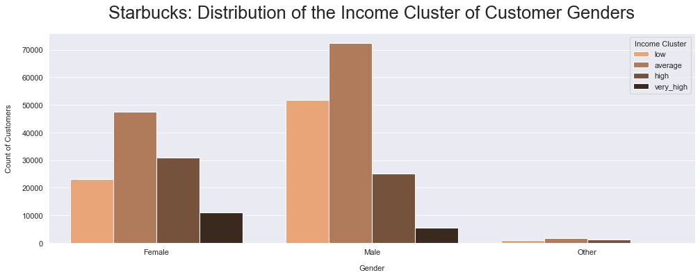

```python
# Calling the function"f_fig_axes()"
f_fig_axes()

# Plotting income cluster of customer genders.
plot_q5 = sns.countplot(data=df_data_q5, x='gender', hue='income_cluster', palette='copper_r')

# Defining the title, the lables and the ticks
plt.title('Starbucks: Distribution of the Income Cluster of Customer Genders', fontsize=23, y=1.05)
plt.xlabel('Gender', labelpad=12)
plt.xlabels = ['Female', 'Male', 'Other'] # Renaming the x axis values
plot_q5.set_xticklabels(plt.xlabels)
plt.ylabel('Count of Customers', labelpad=12)

# Defining legend
plt.legend(title='Income Cluster', loc='upper right')

# Saving the plot as a picture
plt.savefig('pics/plot_q5_gender_income_cluster.png', dpi=300, bbox_inches = "tight");
```

**Conclusion:**

1. **Major Customer Group:** The distribution of the income clusters of customer genders depicts that adult males are the major customer group earning an average income.
2. **Second Biggest Customer Group:** Adult males are the second biggest customer group earning an low income.
3. **Third Biggest Customer Group:** Adult females are the third biggest customer group earning an average income followed by females which have a high wage earning.

## Question 6: How is the distribution of the variable "age" correlated to the offer types?

Table of Content

```python
# Creating clusters for the age
df_data_q6 = df_datav.copy() # Copying the orignal data frame
df_data_q6['age_cluster'] = df_data_q4['age_cluster']
```

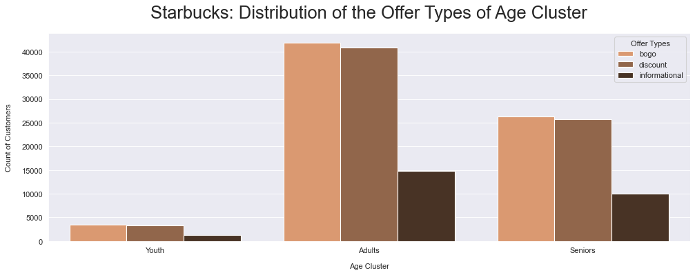

```python
# Calling the function"f_fig_axes()"
f_fig_axes()

# Plotting income cluster of customer genders.
plot_q6 = sns.countplot(data=df_data_q6, x='age_cluster', hue='offer_type', palette='copper_r')

# Defining the title, the lables and the ticks
plt.title('Starbucks: Distribution of the Offer Types of Age Cluster', fontsize=23, y=1.05)
plt.xlabel('Age Cluster', labelpad=12)
plt.ylabel('Count of Customers', labelpad=12)

# Defining legend
plt.legend(title='Offer Types', loc='upper right')

# Saving the plot as a picture
plt.savefig('pics/plot_q6_offer_type_age_cluster.png', dpi=300, bbox_inches = "tight");
```

**Conclusion:**

1. **Major Customer Group:** The distribution of the offer types of customer age depicts that adults are the major customer group receiving the "bogo" and the "discount" offer type.
2. **Second Biggest Customer Group:** Seniors are the second biggest customer group receiving the "bogo" and the "discount" offer type.
3. **Third Biggest Customer Group:** Adults are the third biggest customer group receiving the "informational" offer type.

## Question 7: How is the distribution of the variable "gender" correlated to the offer types?

Table of Content

```python
# Defining the variable for the plot.
df_data_q7 = df_datav.copy() # Copying the orignal data frame
```

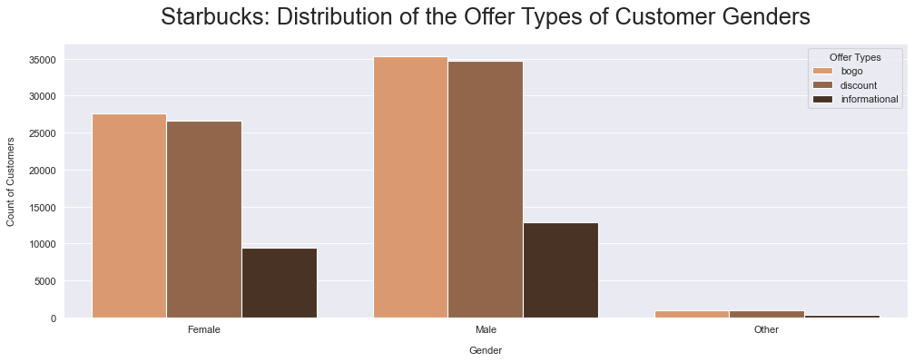

```python
# Calling the function"f_fig_axes()"
f_fig_axes()

# Plotting income cluster of customer genders.
plot_q7 = sns.countplot(data=df_data_q7, x='gender', hue='offer_type', palette='copper_r')

# Defining the title, the lables and the ticks
plt.title('Starbucks: Distribution of the Offer Types of Customer Genders', fontsize=23, y=1.05)
plt.xlabel('Gender', labelpad=12)
plt.xlabels = ['Female', 'Male', 'Other'] # Renaming the x axis values
plot_q7.set_xticklabels(plt.xlabels)
plt.ylabel('Count of Customers', labelpad=12)

# Defining legend
plt.legend(title='Offer Types', loc='upper right')

# Saving the plot as a picture
plt.savefig('pics/plot_q7_offer_type_gender.png', dpi=300, bbox_inches = "tight");
```

**Conclusion:**

1. **Major Customer Group:** The distribution of the offer types of customer genders depicts that males are the major customer group receiving the "bogo" and the "discount" offer type.
2. **Second Biggest Customer Group:** Females are the second biggest customer group receiving the "bogo" and the "discount" offer type.
3. **Third Biggest Customer Group:** Males are the third biggest customer group receiving the "informational" offer type.

## Question 8: How is the distribution of the variable "gender" correlated to the events?

Table of Content

```python
# Defining the variable for the plot.
df_data_q8 = df_datav.copy() # Copying the orignal data frame
```

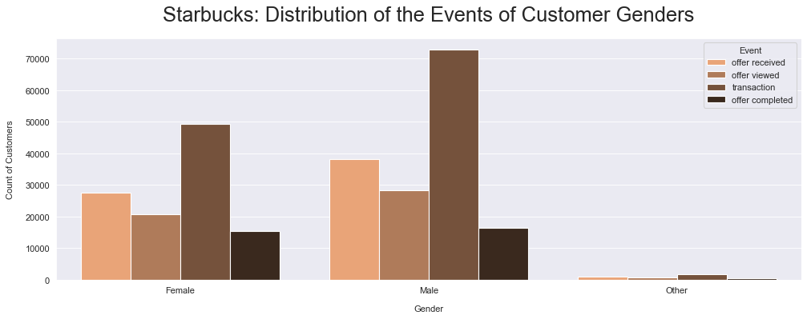

```python
# Calling the function"f_fig_axes()"
f_fig_axes()

# Plotting income cluster of customer genders.
plot_q8 = sns.countplot(data=df_data_q8, x='gender', hue='event', palette='copper_r')

# Defining the title, the lables and the ticks
plt.title('Starbucks: Distribution of the Events of Customer Genders', fontsize=23, y=1.05)
plt.xlabel('Gender', labelpad=12)
plt.xlabels = ['Female', 'Male', 'Other'] # Renaming the x axis values
plot_q8.set_xticklabels(plt.xlabels)
plt.ylabel('Count of Customers', labelpad=12)

# Defining legend
plt.legend(title='Event', loc='upper right');

# Saving the plot as a picture
plt.savefig('pics/plot_q8.1_gender_event.png', dpi=300, bbox_inches = "tight");
```

```python
# Defining separate gender data frames.
df_data_q8_f = df_data_q8[df_data_q8['gender'] == 'F']
df_data_q8_f = df_data_q8_f.astype(str).groupby('event').agg({'gender':'count'})

df_data_q8_m = df_data_q8[df_data_q8['gender'] == 'M']
df_data_q8_m = df_data_q8_m.astype(str).groupby('event').agg({'gender':'count'})

print(df_data_q8_f)
print(df_data_q8_m)
```

```
                 gender
event
offer completed   15477
offer received    27456
offer viewed      20786
transaction       49382
                 gender
event
offer completed   16466
offer received    38129
offer viewed      28301
transaction       72794
```

```python
# Defining the variable for the plot.
df_data_q8_f['eve_perc'] = (df_data_q8_f['gender']/df_data_q8['gender'].count())*100
df_data_q8_f = df_data_q8_f['eve_perc']

df_data_q8_m['eve_perc'] = (df_data_q8_m['gender']/df_data_q8['gender'].count())*100
df_data_q8_m = df_data_q8_m['eve_perc']

print(df_data_q8_f.head())
print(df_data_q8_m.head())
```

```
event
offer completed     5.674177
offer received     10.065918
offer viewed        7.620563
transaction        18.104428
Name: eve_perc, dtype: float64
event
offer completed     6.036765
offer received     13.978853
offer viewed       10.375712
transaction        26.687735
Name: eve_perc, dtype: float64
```

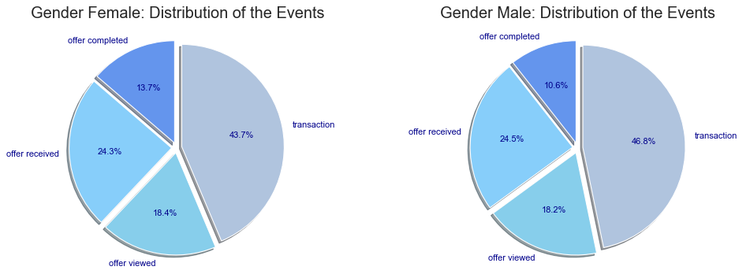

```python
# Plotting the immediate booking possibility of apartments.

# Calling the function"f_fig_axes()"
f_fig_axes() # Python Function

### Female ###
# Defining the plot variables.
plot_labels = ('offer completed', 'offer received', 'offer viewed', 'transaction')
plot_base_color = ['cornflowerblue', 'lightskyblue', 'skyblue', 'lightsteelblue']
plot_explode = (0.05, 0.05, 0.05, 0.05)  # Exploding the 4 slices (gapping)

# Defining the plot.
plt.subplot(1, 2, 1)
plt.pie(df_data_q8_f, explode=plot_explode, labels=plot_labels, autopct='%1.1f%%', shadow=True,
        startangle=90, colors=plot_base_color, textprops=dict(color="darkblue"))
plt.axis('equal')  # Ensuring that pie is drawn as a circle.

# Defining the title
plt.title('Gender Female: Distribution of the Events', fontsize=18, y=1.03)

### Male ###
# Defining the plot variables.
plot_labels = ('offer completed', 'offer received', 'offer viewed', 'transaction')
plot_base_color = ['cornflowerblue', 'lightskyblue', 'skyblue', 'lightsteelblue']
plot_explode = (0.05, 0.05, 0.05, 0.05)  # Exploding the 4 slices (gapping)

# Defining the plot.
plt.subplot(1, 2, 2)
plt.pie(df_data_q8_m, explode=plot_explode, labels=plot_labels, autopct='%1.1f%%', shadow=True,
        startangle=90, colors=plot_base_color, textprops=dict(color="darkblue"))
plt.axis('equal')  # Ensuring that pie is drawn as a circle.

# Defining the title
plt.title('Gender Male: Distribution of the Events', fontsize=18, y=1.03)



# Saving as a picture
plt.savefig('pics/plot_g8.2_gender_f_event_pie.png', dpi=300);
```

**Conclusion:**

## Question 9: How is the distribution of the variable "age" correlated to the events?

Table of Content

```python
# Creating clusters for the age
df_data_q9 = df_datav.copy() # Copying the orignal data frame
df_data_q9['age_cluster'] = df_data_q4['age_cluster']
```

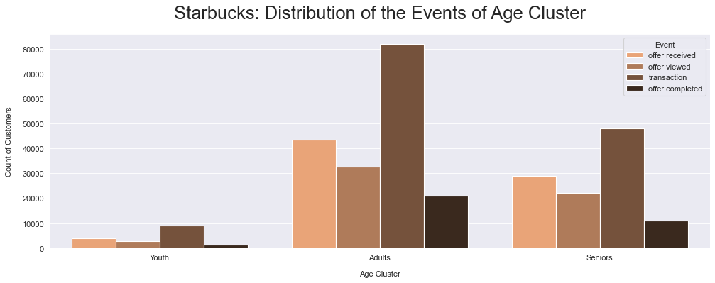

```python
# Calling the function"f_fig_axes()"
f_fig_axes()

# Plotting income cluster of customer genders.
plot_q9 = sns.countplot(data=df_data_q9, x='age_cluster', hue='event', palette='copper_r')

# Defining the title, the lables and the ticks
plt.title('Starbucks: Distribution of the Events of Age Cluster', fontsize=23, y=1.05)
plt.xlabel('Age Cluster', labelpad=12)
plt.ylabel('Count of Customers', labelpad=12)

# Defining legend
plt.legend(title='Event', loc='upper right');

# Saving the plot as a picture
plt.savefig('pics/plot_q9.1_age_cluster_event.png', dpi=300, bbox_inches = "tight");
```

```python
# Defining separate gender data frames.
df_data_q9_s = df_data_q9[df_data_q9['age_cluster'] == 'Seniors'].groupby('event').count()
df_data_q9_a = df_data_q9[df_data_q9['age_cluster'] == 'Adults'].groupby('event').count()

print(df_data_q9_s['age_cluster'])
print(df_data_q9_a['age_cluster'])
```

```
event
offer completed    10972
offer received     28849
offer viewed       22223
transaction        48164
Name: age_cluster, dtype: int64
event
offer completed    21141
offer received     43490
offer viewed       32781
transaction        81860
Name: age_cluster, dtype: int64
```

```python
# Defining the variable for the plot.
df_data_q9_s['eve_perc'] = (df_data_q9_s['age_cluster']/df_data_q9['age_cluster'].count())*100
df_data_q9_s = df_data_q9_s['eve_perc']

df_data_q9_a['eve_perc'] = (df_data_q9_a['age_cluster']/df_data_q9['age_cluster'].count())*100
df_data_q9_a = df_data_q9_a['eve_perc']

print(df_data_q9_s.head())
print(df_data_q9_a.head())
```

```
event
offer completed     3.579375
offer received      9.411354
offer viewed        7.249767
transaction        15.712450
Name: eve_perc, dtype: float64
event
offer completed     6.896788
offer received     14.187659
offer viewed       10.694083
transaction        26.705031
Name: eve_perc, dtype: float64
```

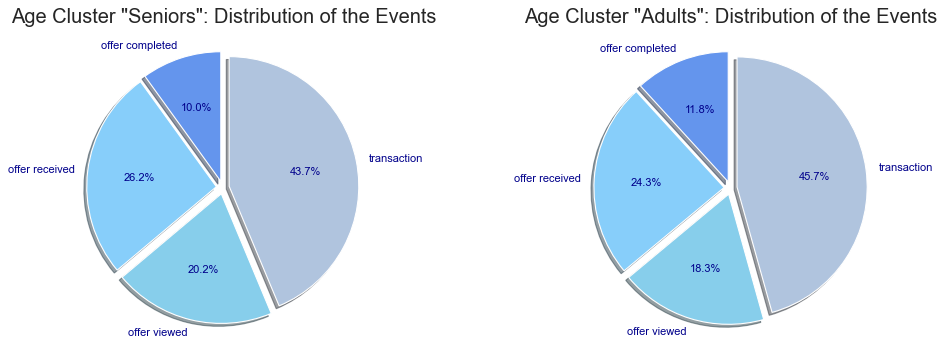

```python
# Plotting the immediate booking possibility of apartments.

# Calling the function"f_fig_axes()"
f_fig_axes() # Python Function

### Female ###
# Defining the plot variables.
plot_labels = ('offer completed', 'offer received', 'offer viewed', 'transaction')
plot_base_color = ['cornflowerblue', 'lightskyblue', 'skyblue', 'lightsteelblue']
plot_explode = (0.05, 0.05, 0.05, 0.05)  # Exploding the 4 slices (gapping)

# Defining the plot.
plt.subplot(1, 2, 1)
plt.pie(df_data_q9_s, explode=plot_explode, labels=plot_labels, autopct='%1.1f%%', shadow=True,
        startangle=90, colors=plot_base_color, textprops=dict(color="darkblue"))
plt.axis('equal')  # Ensuring that pie is drawn as a circle.

# Defining the title
plt.title('Age Cluster "Seniors": Distribution of the Events', fontsize=18, y=1.03)

### Male ###
# Defining the plot variables.
plot_labels = ('offer completed', 'offer received', 'offer viewed', 'transaction')
plot_base_color = ['cornflowerblue', 'lightskyblue', 'skyblue', 'lightsteelblue']
plot_explode = (0.05, 0.05, 0.05, 0.05)  # Exploding the 4 slices (gapping)

# Defining the plot.
plt.subplot(1, 2, 2)
plt.pie(df_data_q9_a, explode=plot_explode, labels=plot_labels, autopct='%1.1f%%', shadow=True,
        startangle=90, colors=plot_base_color, textprops=dict(color="darkblue"))
plt.axis('equal')  # Ensuring that pie is drawn as a circle.

# Defining the title
plt.title('Age Cluster "Adults": Distribution of the Events', fontsize=18, y=1.03)


# Saving as a picture
plt.savefig('pics/plot_g9.2_age_cluster_f_event_pie.png', dpi=300);
```

**Conclusion:**

1. **Major Customer Group:** The distribution of the events of customer age depicts that adults are the major customer group doing a "transaction" and a "offer completed".
2. **Second Biggest Customer Group:** Seniors are the second biggest customer group doing a "transaction" and a "offer completed".
3. **Third Biggest Customer Group:** Adults are the third biggest customer group "receiving" and "viewing" an offer.
4. **Insight:** The relative distribution of the events considering "Seniors" and "Adults" age clusters depicts that both age clusters have an almost equal percentage share of around *55%*

# 4. Section 3: Methodology

Table of Content

## 4. A. Data Preprocessing

Table of Content

#### Description of the steps taken to preprocess the data and address any abnormalities in the data sets. If data preprocessing is not needed, the reasons will be explained.

```python
# Loading the final saved data frame
df_prepro = df_final.copy()
#df_prepro = pd.read_csv('data/data.csv', engine='python')
```

```python
# Calculating the output percentage of values that are missing
# (Source of code parts: Udacity - Data Scientist Nanodegree Program)
df_prepro_missing_val = 100 * df_prepro.isnull().sum() / df_prepro.shape[0]
df_prepro_missing_val
```

```
customer_id          0.000000
event                0.000000
time                 0.000000
value_amount        54.669629
offer_id            45.330371
channels            45.330371
difficulty          45.330371
duration            45.330371
offer_type          45.330371
reward              45.330371
gender              11.017375
age                  0.000000
became_member_on     0.000000
income              11.017375
dtype: float64
```

## Eliminating Outliers of variable "age"

Table of Content

**Function** to help to remove ouliers from the data frame as a preparation for the machine learning model.

```python
# Function: Function that uses the Tukey rule to detect outliers in a dataframe column
# and removes that entire row from the data frame.
# (Source of code parts: Udacity - Data Scientist Nanodegree Program)

def f_remove_outliers_tukey_rule(df, col_name):
    '''
    INPUT:
    df - Pandas data frame.
    col_name - Name of the column of the data frame.

    OUTPUT:
    df - The output is a data frame with the outliers eliminated.

    Description:
    Function that uses the Tukey rule to detect outliers in a dataframe column
    and removes that entire row from the data frame.
    Call the function like:
        for col in ['col_name']:
            df = f_remove_outliers_tukey_rule(df, col)
    '''
    data = df[col_name]
    Q1 = data.quantile(0.25)
    Q3 = data.quantile(0.75)

    IQR = Q3 - Q1

    max_value = Q3 + 1.5 * IQR
    min_value = Q1 - 1.5 * IQR

    return df[(df[col_name] < max_value) & (df[col_name] > min_value)]
```

```python
# Using the function: f_remove_outliers_tukey_rule
for col in ['age']:
    df_prepro = f_remove_outliers_tukey_rule(df_prepro, col)
```

#### Test

```python
# Calculating the descriptive statistics of the "age" values
# (50 % is equal to the median)
df_prepro['age'].describe()
```

```
count    272762.000000
mean         53.840696
std          17.551337
min          18.000000
25%          41.000000
50%          55.000000
75%          66.000000
max         101.000000
Name: age, dtype: float64
```

```python
# Checking the shape of the data frame
df_prepro.shape
```

```
(272762, 14)
```

**Result:** The outliers of variable "age" are completely removed.

## Imputing Missing Values

Table of Content

```python
# Checking the number of missing values
df_prepro.isnull().sum()
```

```
customer_id              0
event                    0
time                     0
value_amount        148805
offer_id            123957
channels            123957
difficulty          123957
duration            123957
offer_type          123957
reward              123957
gender                   0
age                      0
became_member_on         0
income                   0
dtype: int64
```

**Function** to help to impute missing values from the data frame as a preparation for the machine learning model.

```python
# Function: Function that imputes missing values in a dataframe column.
def f_impute_values_col_zero(df, col_list):
    '''
    INPUT:
    df - Pandas data frame.
    col_list - List of the column names of the data frame (e.g. ['col_1', 'col_2', ...]).

    OUTPUT:
    df - The output is a data frame with imputed missing values.

    Description:
    Function that imputes NaN values of a column in a dataframe column with "0".
    '''
    # Imputing values for all CATEGORIAL  and NUMERICAL columns.
    for i in col_list:
        df[i] = df[i].fillna(value=0)

    return df
```

```python
# Using the function: f_impute_values_col_zero
df_prepro = f_impute_values_col_zero(df_prepro, ['value_amount',
                                                 'offer_id',
                                                 'difficulty',
                                                 'duration',
                                                 'offer_type',
                                                 'reward'])
```

#### Test

```python
# Checking the number of missing values
df_prepro.isnull().sum()
```

```
customer_id              0
event                    0
time                     0
value_amount             0
offer_id                 0
channels            123957
difficulty               0
duration                 0
offer_type               0
reward                   0
gender                   0
age                      0
became_member_on         0
income                   0
dtype: int64
```

**Result:** The corresponding missing values are imputed.

## *Dropping Missing Values (Discarded - Not used)*

Table of Content

**Function** to help to drop rows with missing values from the data frame as a preparation for the machine learning model.

```python
# Function: Function that drops rows with missing values from the data frame.
def f_drop_NaN_rows(df, col_list):
    '''
    INPUT:
    df - Pandas data frame.
    col_name - Name of the column of the data frame. ( e.g. ['col_1', 'col_2', 'col_3'])

    OUTPUT:
    df - The output is a data frame with dropped missing value rows.

    Description:
    Function that drops rows with missing values from the data frame.
    '''
    # Dropping rows with not needed NaN values in specific columns.
    df = df.dropna(subset=col_list, how='any')

    return df
```

```python
# Using the function: f_drop_NaN_rows
#df_prepro = f_drop_NaN_rows(df_prepro, ['offer_id'])
```

## Splitting the variable "channels" in categorical variables based on its values

Table of Content

```python
# Displaying the new data frame to check the changes
df_prepro.head()
```

|  | customer_id | event | time | value_amount | offer_id | channels | difficulty | duration | offer_type | reward | gender | age | became_member_on | income |
| --- | --- | --- | --- | --- | --- | --- | --- | --- | --- | --- | --- | --- | --- | --- |
| 0 | 78afa995795e4d85b5d9ceeca43f5fef | offer received | 0 | 0.0 | 9b98b8c7a33c4b65b9aebfe6a799e6d9 | [web, email, mobile] | 5.0 | 7.0 | bogo | 5.0 | F | 75 | 2017-05-09 | 100000.0 |
| 2 | e2127556f4f64592b11af22de27a7932 | offer received | 0 | 0.0 | 2906b810c7d4411798c6938adc9daaa5 | [web, email, mobile] | 10.0 | 7.0 | discount | 2.0 | M | 68 | 2018-04-26 | 70000.0 |
| 5 | 389bc3fa690240e798340f5a15918d5c | offer received | 0 | 0.0 | f19421c1d4aa40978ebb69ca19b0e20d | [web, email, mobile, social] | 5.0 | 5.0 | bogo | 5.0 | M | 65 | 2018-02-09 | 53000.0 |
| 7 | 2eeac8d8feae4a8cad5a6af0499a211d | offer received | 0 | 0.0 | 3f207df678b143eea3cee63160fa8bed | [web, email, mobile] | 0.0 | 4.0 | informational | 0.0 | M | 58 | 2017-11-11 | 51000.0 |
| 8 | aa4862eba776480b8bb9c68455b8c2e1 | offer received | 0 | 0.0 | 0b1e1539f2cc45b7b9fa7c272da2e1d7 | [web, email] | 20.0 | 10.0 | discount | 5.0 | F | 61 | 2017-09-11 | 57000.0 |

**Function** to help to create the data frame including dummies as a preparation for the machine learning model.

```python
# Function: Defining function to create a list of the column names of the categorical variables.
# (Source of code parts: Udacity - Data Scientist Nanodegree Program)
def f_create_dummy_df(df, cat_cols, dummy_na):
    '''
    INPUT:
    df - Pandas data frame with categorical variables to create dummies.
    cat_cols - List of names (strings) of the categorical columns.
    dummy_na - Bool holding whether you want to dummy NA vals of categorical columns or not

    OUTPUT:
    df - New dataframe of the following characteristics:
            1. Contains all not categorical columns.
            2. Removes the original columns in cat_cols (all).
            3. Dummy each categorical columns in cat_cols.
            4. dummy_na == TRUE - It does contain dummy columns for NaN values.
            5. Prefix of the column name: Underscore (_) for separating.

    Description:
    Splits values of an variable into categorical variables.
    '''
    for col in  cat_cols:
        try:
            #for each cat add dummy var, drop original column
            df = pd.concat([df.drop(cat_cols, axis=1),
                            pd.get_dummies(df[cat_cols].apply(pd.Series).stack(), prefix=cat_cols,
                            prefix_sep='_', drop_first=False, dummy_na=dummy_na).groupby(level=0).sum().astype('int64')],
                           axis=1)
        except:
            continue


    df.columns = df.columns.str.replace(' ','_')

    return df
```

**Result:** A function is created to split values of an variable into categorical variables.

##### **Creating** a new data frame including the dummies for all categorial variables.

```python
# Using the function: f_create_dummy_df
df_prepro = f_create_dummy_df(df_prepro, 'channels', dummy_na=False)
```

```python
# Using the function: f_impute_values_col_zero
df_prepro = f_impute_values_col_zero(df_prepro, ['channels_email',
                                                 'channels_mobile',
                                                 'channels_social',
                                                 'channels_web'])
```

#### Test

```python
# Displaying the new data frame to check the changes
df_prepro.head()
```

|  | customer_id | event | time | value_amount | offer_id | difficulty | duration | offer_type | reward | gender | age | became_member_on | income | channels_email | channels_mobile | channels_social | channels_web |
| --- | --- | --- | --- | --- | --- | --- | --- | --- | --- | --- | --- | --- | --- | --- | --- | --- | --- |
| 0 | 78afa995795e4d85b5d9ceeca43f5fef | offer received | 0 | 0.0 | 9b98b8c7a33c4b65b9aebfe6a799e6d9 | 5.0 | 7.0 | bogo | 5.0 | F | 75 | 2017-05-09 | 100000.0 | 1.0 | 1.0 | 0.0 | 1.0 |
| 2 | e2127556f4f64592b11af22de27a7932 | offer received | 0 | 0.0 | 2906b810c7d4411798c6938adc9daaa5 | 10.0 | 7.0 | discount | 2.0 | M | 68 | 2018-04-26 | 70000.0 | 1.0 | 1.0 | 0.0 | 1.0 |
| 5 | 389bc3fa690240e798340f5a15918d5c | offer received | 0 | 0.0 | f19421c1d4aa40978ebb69ca19b0e20d | 5.0 | 5.0 | bogo | 5.0 | M | 65 | 2018-02-09 | 53000.0 | 1.0 | 1.0 | 1.0 | 1.0 |
| 7 | 2eeac8d8feae4a8cad5a6af0499a211d | offer received | 0 | 0.0 | 3f207df678b143eea3cee63160fa8bed | 0.0 | 4.0 | informational | 0.0 | M | 58 | 2017-11-11 | 51000.0 | 1.0 | 1.0 | 0.0 | 1.0 |
| 8 | aa4862eba776480b8bb9c68455b8c2e1 | offer received | 0 | 0.0 | 0b1e1539f2cc45b7b9fa7c272da2e1d7 | 20.0 | 10.0 | discount | 5.0 | F | 61 | 2017-09-11 | 57000.0 | 1.0 | 0.0 | 0.0 | 1.0 |

```python
# Checking the shape of the data frame
df_prepro.shape
```

```
(272762, 17)
```

**Result:** The variable "channels" is split in categorical variables based on its values.

## Splitting the variable "event" in categorical variables based on its values

Table of Content

```python
# Using the function: f_create_dummy_df
df_prepro = f_create_dummy_df(df_prepro, 'event', dummy_na=False)
```

#### Test

```python
# Displaying the new data frame to check the changes
df_prepro.head()
```

|  | customer_id | time | value_amount | offer_id | difficulty | duration | offer_type | reward | gender | age | became_member_on | income | channels_email | channels_mobile | channels_social | channels_web | event_offer_completed | event_offer_received | event_offer_viewed | event_transaction |
| --- | --- | --- | --- | --- | --- | --- | --- | --- | --- | --- | --- | --- | --- | --- | --- | --- | --- | --- | --- | --- |
| 0 | 78afa995795e4d85b5d9ceeca43f5fef | 0 | 0.0 | 9b98b8c7a33c4b65b9aebfe6a799e6d9 | 5.0 | 7.0 | bogo | 5.0 | F | 75 | 2017-05-09 | 100000.0 | 1.0 | 1.0 | 0.0 | 1.0 | 0 | 1 | 0 | 0 |
| 2 | e2127556f4f64592b11af22de27a7932 | 0 | 0.0 | 2906b810c7d4411798c6938adc9daaa5 | 10.0 | 7.0 | discount | 2.0 | M | 68 | 2018-04-26 | 70000.0 | 1.0 | 1.0 | 0.0 | 1.0 | 0 | 1 | 0 | 0 |
| 5 | 389bc3fa690240e798340f5a15918d5c | 0 | 0.0 | f19421c1d4aa40978ebb69ca19b0e20d | 5.0 | 5.0 | bogo | 5.0 | M | 65 | 2018-02-09 | 53000.0 | 1.0 | 1.0 | 1.0 | 1.0 | 0 | 1 | 0 | 0 |
| 7 | 2eeac8d8feae4a8cad5a6af0499a211d | 0 | 0.0 | 3f207df678b143eea3cee63160fa8bed | 0.0 | 4.0 | informational | 0.0 | M | 58 | 2017-11-11 | 51000.0 | 1.0 | 1.0 | 0.0 | 1.0 | 0 | 1 | 0 | 0 |
| 8 | aa4862eba776480b8bb9c68455b8c2e1 | 0 | 0.0 | 0b1e1539f2cc45b7b9fa7c272da2e1d7 | 20.0 | 10.0 | discount | 5.0 | F | 61 | 2017-09-11 | 57000.0 | 1.0 | 0.0 | 0.0 | 1.0 | 0 | 1 | 0 | 0 |

```python
# Checking the shape of the data frame
df_prepro.shape
```

```
(272762, 20)
```

**Result:** The variable "event" is split in categorical variables based on its values.

## Splitting the variable "offer_type" in categorical variables based on its values

Table of Content

```python
# Using the function: f_create_dummy_df
df_prepro = f_create_dummy_df(df_prepro, 'offer_type', dummy_na=False)
```

#### Test

```python
# Displaying the new data frame to check the changes
df_prepro.head()
```

|  | customer_id | time | value_amount | offer_id | difficulty | duration | reward | gender | age | became_member_on | ... | channels_social | channels_web | event_offer_completed | event_offer_received | event_offer_viewed | event_transaction | offer_type_0 | offer_type_bogo | offer_type_discount | offer_type_informational |
| --- | --- | --- | --- | --- | --- | --- | --- | --- | --- | --- | --- | --- | --- | --- | --- | --- | --- | --- | --- | --- | --- |
| 0 | 78afa995795e4d85b5d9ceeca43f5fef | 0 | 0.0 | 9b98b8c7a33c4b65b9aebfe6a799e6d9 | 5.0 | 7.0 | 5.0 | F | 75 | 2017-05-09 | ... | 0.0 | 1.0 | 0 | 1 | 0 | 0 | 0 | 1 | 0 | 0 |
| 2 | e2127556f4f64592b11af22de27a7932 | 0 | 0.0 | 2906b810c7d4411798c6938adc9daaa5 | 10.0 | 7.0 | 2.0 | M | 68 | 2018-04-26 | ... | 0.0 | 1.0 | 0 | 1 | 0 | 0 | 0 | 0 | 1 | 0 |
| 5 | 389bc3fa690240e798340f5a15918d5c | 0 | 0.0 | f19421c1d4aa40978ebb69ca19b0e20d | 5.0 | 5.0 | 5.0 | M | 65 | 2018-02-09 | ... | 1.0 | 1.0 | 0 | 1 | 0 | 0 | 0 | 1 | 0 | 0 |
| 7 | 2eeac8d8feae4a8cad5a6af0499a211d | 0 | 0.0 | 3f207df678b143eea3cee63160fa8bed | 0.0 | 4.0 | 0.0 | M | 58 | 2017-11-11 | ... | 0.0 | 1.0 | 0 | 1 | 0 | 0 | 0 | 0 | 0 | 1 |
| 8 | aa4862eba776480b8bb9c68455b8c2e1 | 0 | 0.0 | 0b1e1539f2cc45b7b9fa7c272da2e1d7 | 20.0 | 10.0 | 5.0 | F | 61 | 2017-09-11 | ... | 0.0 | 1.0 | 0 | 1 | 0 | 0 | 0 | 0 | 1 | 0 |

5 rows × 23 columns

```python
# Checking the shape of the data frame
df_prepro.shape
```

```
(272762, 23)
```

**Result:** The variable "offer_type" is split in categorical variables based on its values.

## Splitting the variable "gender" in categorical variables based on its values

Table of Content

```python
# Using the function: f_create_dummy_df
df_prepro = f_create_dummy_df(df_prepro, 'gender', dummy_na=False)
```

#### Test

```python
# Displaying the new data frame to check the changes
df_prepro.head()
```

|  | customer_id | time | value_amount | offer_id | difficulty | duration | reward | age | became_member_on | income | ... | event_offer_received | event_offer_viewed | event_transaction | offer_type_0 | offer_type_bogo | offer_type_discount | offer_type_informational | gender_F | gender_M | gender_O |
| --- | --- | --- | --- | --- | --- | --- | --- | --- | --- | --- | --- | --- | --- | --- | --- | --- | --- | --- | --- | --- | --- |
| 0 | 78afa995795e4d85b5d9ceeca43f5fef | 0 | 0.0 | 9b98b8c7a33c4b65b9aebfe6a799e6d9 | 5.0 | 7.0 | 5.0 | 75 | 2017-05-09 | 100000.0 | ... | 1 | 0 | 0 | 0 | 1 | 0 | 0 | 1 | 0 | 0 |
| 2 | e2127556f4f64592b11af22de27a7932 | 0 | 0.0 | 2906b810c7d4411798c6938adc9daaa5 | 10.0 | 7.0 | 2.0 | 68 | 2018-04-26 | 70000.0 | ... | 1 | 0 | 0 | 0 | 0 | 1 | 0 | 0 | 1 | 0 |
| 5 | 389bc3fa690240e798340f5a15918d5c | 0 | 0.0 | f19421c1d4aa40978ebb69ca19b0e20d | 5.0 | 5.0 | 5.0 | 65 | 2018-02-09 | 53000.0 | ... | 1 | 0 | 0 | 0 | 1 | 0 | 0 | 0 | 1 | 0 |
| 7 | 2eeac8d8feae4a8cad5a6af0499a211d | 0 | 0.0 | 3f207df678b143eea3cee63160fa8bed | 0.0 | 4.0 | 0.0 | 58 | 2017-11-11 | 51000.0 | ... | 1 | 0 | 0 | 0 | 0 | 0 | 1 | 0 | 1 | 0 |
| 8 | aa4862eba776480b8bb9c68455b8c2e1 | 0 | 0.0 | 0b1e1539f2cc45b7b9fa7c272da2e1d7 | 20.0 | 10.0 | 5.0 | 61 | 2017-09-11 | 57000.0 | ... | 1 | 0 | 0 | 0 | 0 | 1 | 0 | 1 | 0 | 0 |

5 rows × 25 columns

```python
# Checking the shape of the data frame
df_prepro.shape
```

```
(272762, 25)
```

**Result:** The variable "gender" is split in categorical variables based on its values.

## Splitting the variable "age" in categorical variables based on its values

Table of Content

```python
# Creating clusters for the age
df_prepro['age_cluster'] = (pd.cut(df_prepro['age'], bins=[15, 24, 64, 120], labels=['Youth', 'Adults', 'Seniors'])).astype('object')
```

```python
# Using the function: f_create_dummy_df
df_prepro = f_create_dummy_df(df_prepro, 'age_cluster', dummy_na=False)
```

#### Test

```python
# Displaying the new data frame to check the changes
df_prepro.head()
```

|  | customer_id | time | value_amount | offer_id | difficulty | duration | reward | age | became_member_on | income | ... | offer_type_0 | offer_type_bogo | offer_type_discount | offer_type_informational | gender_F | gender_M | gender_O | age_cluster_Adults | age_cluster_Seniors | age_cluster_Youth |
| --- | --- | --- | --- | --- | --- | --- | --- | --- | --- | --- | --- | --- | --- | --- | --- | --- | --- | --- | --- | --- | --- |
| 0 | 78afa995795e4d85b5d9ceeca43f5fef | 0 | 0.0 | 9b98b8c7a33c4b65b9aebfe6a799e6d9 | 5.0 | 7.0 | 5.0 | 75 | 2017-05-09 | 100000.0 | ... | 0 | 1 | 0 | 0 | 1 | 0 | 0 | 0 | 1 | 0 |
| 2 | e2127556f4f64592b11af22de27a7932 | 0 | 0.0 | 2906b810c7d4411798c6938adc9daaa5 | 10.0 | 7.0 | 2.0 | 68 | 2018-04-26 | 70000.0 | ... | 0 | 0 | 1 | 0 | 0 | 1 | 0 | 0 | 1 | 0 |
| 5 | 389bc3fa690240e798340f5a15918d5c | 0 | 0.0 | f19421c1d4aa40978ebb69ca19b0e20d | 5.0 | 5.0 | 5.0 | 65 | 2018-02-09 | 53000.0 | ... | 0 | 1 | 0 | 0 | 0 | 1 | 0 | 0 | 1 | 0 |
| 7 | 2eeac8d8feae4a8cad5a6af0499a211d | 0 | 0.0 | 3f207df678b143eea3cee63160fa8bed | 0.0 | 4.0 | 0.0 | 58 | 2017-11-11 | 51000.0 | ... | 0 | 0 | 0 | 1 | 0 | 1 | 0 | 1 | 0 | 0 |
| 8 | aa4862eba776480b8bb9c68455b8c2e1 | 0 | 0.0 | 0b1e1539f2cc45b7b9fa7c272da2e1d7 | 20.0 | 10.0 | 5.0 | 61 | 2017-09-11 | 57000.0 | ... | 0 | 0 | 1 | 0 | 1 | 0 | 0 | 1 | 0 | 0 |

5 rows × 28 columns

```python
# Checking the shape of the data frame
df_prepro.shape
```

```
(272762, 28)
```

**Result:** The variable "age" is split in categorical variables based on its values.

## Creating new variable "row_count"

Table of Content

```python
# Creating a new column which includes the rows numeration
df_prepro['row_count'] = np.arange(df_prepro.shape[0])
```

#### Test

```python
# Displaying the new data frame to check the changes
df_prepro.head()
```

|  | customer_id | time | value_amount | offer_id | difficulty | duration | reward | age | became_member_on | income | ... | offer_type_bogo | offer_type_discount | offer_type_informational | gender_F | gender_M | gender_O | age_cluster_Adults | age_cluster_Seniors | age_cluster_Youth | row_count |
| --- | --- | --- | --- | --- | --- | --- | --- | --- | --- | --- | --- | --- | --- | --- | --- | --- | --- | --- | --- | --- | --- |
| 0 | 78afa995795e4d85b5d9ceeca43f5fef | 0 | 0.0 | 9b98b8c7a33c4b65b9aebfe6a799e6d9 | 5.0 | 7.0 | 5.0 | 75 | 2017-05-09 | 100000.0 | ... | 1 | 0 | 0 | 1 | 0 | 0 | 0 | 1 | 0 | 0 |
| 2 | e2127556f4f64592b11af22de27a7932 | 0 | 0.0 | 2906b810c7d4411798c6938adc9daaa5 | 10.0 | 7.0 | 2.0 | 68 | 2018-04-26 | 70000.0 | ... | 0 | 1 | 0 | 0 | 1 | 0 | 0 | 1 | 0 | 1 |
| 5 | 389bc3fa690240e798340f5a15918d5c | 0 | 0.0 | f19421c1d4aa40978ebb69ca19b0e20d | 5.0 | 5.0 | 5.0 | 65 | 2018-02-09 | 53000.0 | ... | 1 | 0 | 0 | 0 | 1 | 0 | 0 | 1 | 0 | 2 |
| 7 | 2eeac8d8feae4a8cad5a6af0499a211d | 0 | 0.0 | 3f207df678b143eea3cee63160fa8bed | 0.0 | 4.0 | 0.0 | 58 | 2017-11-11 | 51000.0 | ... | 0 | 0 | 1 | 0 | 1 | 0 | 1 | 0 | 0 | 3 |
| 8 | aa4862eba776480b8bb9c68455b8c2e1 | 0 | 0.0 | 0b1e1539f2cc45b7b9fa7c272da2e1d7 | 20.0 | 10.0 | 5.0 | 61 | 2017-09-11 | 57000.0 | ... | 0 | 1 | 0 | 1 | 0 | 0 | 1 | 0 | 0 | 4 |

5 rows × 29 columns

```python
# Checking a concise summary of the dataframe
df_prepro.info()
```

```
<class 'pandas.core.frame.DataFrame'>
Int64Index: 272762 entries, 0 to 306532
Data columns (total 29 columns):
 #   Column                    Non-Null Count   Dtype
---  ------                    --------------   -----
 0   customer_id               272762 non-null  object
 1   time                      272762 non-null  int64
 2   value_amount              272762 non-null  float64
 3   offer_id                  272762 non-null  object
 4   difficulty                272762 non-null  float64
 5   duration                  272762 non-null  float64
 6   reward                    272762 non-null  float64
 7   age                       272762 non-null  int64
 8   became_member_on          272762 non-null  datetime64[ns]
 9   income                    272762 non-null  float64
```

[output cut: 21 more lines]

```python
# Checking the shape of the data frame
df_prepro.shape
```

```
(272762, 29)
```

**Result:** The new variable "row_count" is created.

```python
# Copying the data frame
df_clean = df_prepro.copy()
```

**Result:** The data frame is copied.

```python
# Saving data final data frame to .csv
df_clean.to_csv('data/data_clean.csv', index=False)
```

**Result:** The data frame is saved as .csv.

## 4. B. Implementation

Table of Content

#### Discussion about the process using the models, algorithms, and techniques applied to solve the problem. As well as mentioning of any complications during the implementation.

## Creating a machine learning model

Table of Content

**Features:**

**Prediction target:**

- event_offer_completed

```python
# Loading the ML  data frame
df_ml = df_clean.copy()
#df_ml = np.array(df_ml, dtype='float32')
```

```python
# Checking a concise summary of the dataframe
df_ml.info()
```

```
<class 'pandas.core.frame.DataFrame'>
Int64Index: 272762 entries, 0 to 306532
Data columns (total 29 columns):
 #   Column                    Non-Null Count   Dtype
---  ------                    --------------   -----
 0   customer_id               272762 non-null  object
 1   time                      272762 non-null  int64
 2   value_amount              272762 non-null  float64
 3   offer_id                  272762 non-null  object
 4   difficulty                272762 non-null  float64
 5   duration                  272762 non-null  float64
 6   reward                    272762 non-null  float64
 7   age                       272762 non-null  int64
 8   became_member_on          272762 non-null  datetime64[ns]
 9   income                    272762 non-null  float64
```

[output cut: 21 more lines]

## Creating a function for a confusion matrix

Table of Content

```python
# Function: Defining function to create a confusion matrix to predict the most common category of variables.
# (Source of code parts: packtpub.com)
def f_CMatrix(CM, labels=['event_offer_completed', 'offer_type_bogo']):
    '''
    INPUT:
    CM - Confusion matrix input values.
    col_name_1 - List of values of the categorical columns (e.g. ['col_name_1', 'col_name_2']).
    col_name_2 - List of values of the categorical columns (e.g. ['col_name_1', 'col_name_2']).

    OUTPUT:
    df - Data frame based on confusion matrix.

    Description:
    Predicting the most common category of variables.
    '''
    df = pd.DataFrame(data=CM, index=labels, columns=labels)
    df.index.name = 'TRUE'
    df.columns.name = 'PREDICTION'
    df.loc['TOTAL'] = df.sum()
    df['TOTAL'] = df.sum(axis=1)

    return df
```

**Result:** A function is created to predict the most common category of variables.

## Creating a data frame with metrics

Table of Content

Creating a data frame to save the metrics of the models.

```python
# Data frame for evaluation metrics
metrics = pd.DataFrame(index=['accuracy', 'precision', 'recall'],
                      columns=['NULL', 'LogisticReg', 'ClassTree', 'NaiveBayes', 'KNeighbors'])
```

- **Accuracy:** the proportion of the total number of predictions that are correct.  
  (The total, how often the model predicts correctly "completers" and "Non-completers".)
- **Precision:** the proportion of positive predictions that are actually correct.  
  (When the model predicts complete: How often is correct?)
- **Recall:** the proportion of positive observed values correctly predicted as such.  
  (The proportion of actual completers that the model will correctly predict as such.)

**Which metric should be used?**

- **False Positive:** A customer who will complete is predicted as not completed.
- **False Negative:** A customer who did not complete predicted as a completing person.  
  (**Hint:** If *False Negatives* are worse--> A better recall is suggested.)

## Machine learning model inital setup

Table of Content

```python
# Splitting data into explanatory (feature) and response variables (target).
X = df_ml.drop(['event_offer_completed', 'customer_id', 'offer_id', 'became_member_on'], axis=1) # features
y = df_ml['event_offer_completed'] # target

# Instantiating and fitting the Scaler to rescale all the features into the same scale
robust_scaler = RobustScaler()
X = robust_scaler.fit_transform(X)

# Splitting data into train data and test data subsets.
X_train, X_test, y_train, y_test = train_test_split(X, y, test_size=0.5, random_state=123, stratify=y) # test_size=0.5
```

## Model: NULL

Table of Content

This is a model as a benchmark comparison how good the final model has to perform. The NULL model is the simplest model.

**Prediction:** The most common category.

```python
# Instantiating of the estimator
y_pred_test = np.repeat(y_train.value_counts().idxmax(), y_test.size)
#print(y_pred_test)

# Defining metrics of the model
metrics.loc['accuracy', 'NULL'] = accuracy_score(y_pred=y_pred_test, y_true=y_test)
metrics.loc['precision', 'NULL'] = precision_score(y_pred=y_pred_test, y_true=y_test)
metrics.loc['recall', 'NULL'] = recall_score(y_pred=y_pred_test, y_true=y_test)

# Using the function: f_CMatrix
CM = confusion_matrix(y_pred=y_pred_test, y_true=y_test)
f_CMatrix(CM)
```

| PREDICTION TRUE | event_offer_completed | offer_type_bogo | TOTAL |
| --- | --- | --- | --- |
| event_offer_completed | 120159 | 0 | 120159 |
| offer_type_bogo | 16222 | 0 | 16222 |
| TOTAL | 136381 | 0 | 136381 |

**Result:** The most common predicted category out of a total of *136,381* is:

## Model A: Logistic Regression Classifier

Table of Content

The model uses logistic regression for prediction.

**Prediction:** The most common category.

```python
# Instantiating the model.
log_reg = LogisticRegression(n_jobs=-1, random_state=10)

# Fitting the model.
log_reg.fit(X_train, y_train)

# Instantiating of the estimator for the predictions
y_pred_test = log_reg.predict(X_test)

# Defining metrics of the model for evaluation
metrics.loc['accuracy', 'LogisticReg'] = accuracy_score(y_pred=y_pred_test, y_true=y_test)
metrics.loc['precision', 'LogisticReg'] = precision_score(y_pred=y_pred_test, y_true=y_test)
metrics.loc['recall', 'LogisticReg'] = recall_score(y_pred=y_pred_test, y_true=y_test)
print('Accuracy: ', 100*metrics.loc['accuracy', 'LogisticReg'])
print('Precision: ', 100*metrics.loc['precision', 'LogisticReg'])
print('Recall: ', 100*metrics.loc['recall', 'LogisticReg'])

# Using the function: f_CMatrix
CM = confusion_matrix(y_pred=y_pred_test, y_true=y_test)
f_CMatrix(CM)
```

```
Accuracy:  100.0
Precision:  100.0
Recall:  100.0
```

| PREDICTION TRUE | event_offer_completed | offer_type_bogo | TOTAL |
| --- | --- | --- | --- |
| event_offer_completed | 120159 | 0 | 120159 |
| offer_type_bogo | 0 | 16222 | 16222 |
| TOTAL | 120159 | 16222 | 136381 |

- **event_offer_completed** with *120,159* predictions

## Model B: Decision Trees Classifier

Table of Content

The model is decision tree based to make predictions.

**Prediction:** The most common category.

```python
# Instantiating the model.
class_tree = DecisionTreeClassifier(min_samples_split=300, min_samples_leaf=150, random_state=10)
# (Controlling "overfitting" with the parameters of "min_samples_split" and "min_samples_leaf".

# Fitting the model.
class_tree.fit(X_train, y_train)

# Instantiating of the estimator for the predictions
y_pred_test = class_tree.predict(X_test)

# Defining metrics of the model for evaluation
metrics.loc['accuracy', 'ClassTree'] = accuracy_score(y_pred=y_pred_test, y_true=y_test)
metrics.loc['precision', 'ClassTree'] = precision_score(y_pred=y_pred_test, y_true=y_test)
metrics.loc['recall', 'ClassTree'] = recall_score(y_pred=y_pred_test, y_true=y_test)
print('Accuracy: ', 100*metrics.loc['accuracy', 'ClassTree'])
print('Precision: ', 100*metrics.loc['precision', 'ClassTree'])
print('Recall: ', 100*metrics.loc['recall', 'ClassTree'])

# Using the function: f_CMatrix
CM = confusion_matrix(y_pred=y_pred_test, y_true=y_test)
f_CMatrix(CM)
```

```
Accuracy:  100.0
Precision:  100.0
Recall:  100.0
```

| PREDICTION TRUE | event_offer_completed | offer_type_bogo | TOTAL |
| --- | --- | --- | --- |
| event_offer_completed | 120159 | 0 | 120159 |
| offer_type_bogo | 0 | 16222 | 16222 |
| TOTAL | 120159 | 16222 | 136381 |

- **event_offer_completed** with *120,159* predictions

## Model C: Naive Bayes Classifier

Table of Content

The model is based on applying Bayes' theorem with "naive" assumptions between the features.

**Prediction:** The most common category.

```python
# Instantiating the model.
NBC = GaussianNB() # No parameters to setup

# Fitting the model.
NBC.fit(X_train, y_train)

# Instantiating of the estimator for the predictions
y_pred_test = NBC.predict(X_test)

# Defining metrics of the model for evaluation
metrics.loc['accuracy', 'NaiveBayes'] = accuracy_score(y_pred=y_pred_test, y_true=y_test)
metrics.loc['precision', 'NaiveBayes'] = precision_score(y_pred=y_pred_test, y_true=y_test)
metrics.loc['recall', 'NaiveBayes'] = recall_score(y_pred=y_pred_test, y_true=y_test)
print('Accuracy: ', 100*metrics.loc['accuracy', 'NaiveBayes'])
print('Precision: ', 100*metrics.loc['precision', 'NaiveBayes'])
print('Recall: ', 100*metrics.loc['recall', 'NaiveBayes'])

# Using the function: f_CMatrix
CM = confusion_matrix(y_pred=y_pred_test, y_true=y_test)
f_CMatrix(CM)
```

```
Accuracy:  100.0
Precision:  100.0
Recall:  100.0
```

| PREDICTION TRUE | event_offer_completed | offer_type_bogo | TOTAL |
| --- | --- | --- | --- |
| event_offer_completed | 120159 | 0 | 120159 |
| offer_type_bogo | 0 | 16222 | 16222 |
| TOTAL | 120159 | 16222 | 136381 |

- **event_offer_completed** with *120,159* predictions

## Model D: KNeighbors Classifier

Table of Content

The model is based on applying the k-nearest neighbors algorithm.

**Prediction:** The most common category.

```python
# Instantiating the model.
KNN = KNeighborsClassifier() # No parameters to setup

# Fitting the model.
KNN.fit(X_train, y_train)

# Instantiating of the estimator for the predictions
y_pred_test = KNN.predict(X_test)

# Defining metrics of the model for evaluation
metrics.loc['accuracy', 'KNeighbors'] = accuracy_score(y_pred=y_pred_test, y_true=y_test)
metrics.loc['precision', 'KNeighbors'] = precision_score(y_pred=y_pred_test, y_true=y_test)
metrics.loc['recall', 'KNeighbors'] = recall_score(y_pred=y_pred_test, y_true=y_test)
print('Accuracy: ', 100*metrics.loc['accuracy', 'KNeighbors'])
print('Precision: ', 100*metrics.loc['precision', 'KNeighbors'])
print('Recall: ', 100*metrics.loc['recall', 'KNeighbors'])

# Using the function: f_CMatrix
CM = confusion_matrix(y_pred=y_pred_test, y_true=y_test)
f_CMatrix(CM)
```

```
Accuracy:  99.97067040130223
Precision:  99.93827922478707
Recall:  99.81506595980767
```

| PREDICTION TRUE | event_offer_completed | offer_type_bogo | TOTAL |
| --- | --- | --- | --- |
| event_offer_completed | 120149 | 10 | 120159 |
| offer_type_bogo | 30 | 16192 | 16222 |
| TOTAL | 120179 | 16202 | 136381 |

- **event_offer_completed** with *120149* predictions

## 4. C. Refinement

Table of Content

## Metrics

Table of Content

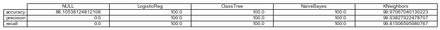

```python
# Displaying the data Frame of Metrics in percentage [%]
metrics = np.round((100*metrics), decimals=2)
metrics

# Plotting the table
fig, axs = plt.subplots(2, 2, figsize=(15, 0.01))
ax = plt.subplot(111, frame_on=False) # no visible frame
ax.xaxis.set_visible(False)  # hide the x axis
ax.yaxis.set_visible(False)  # hide the y axis

table(ax, metrics);

# Saving as a picture
plt.savefig('metrics/plot_m1.1_metrics_table.png', dpi=300, bbox_inches = "tight", pad_inches=0);
```

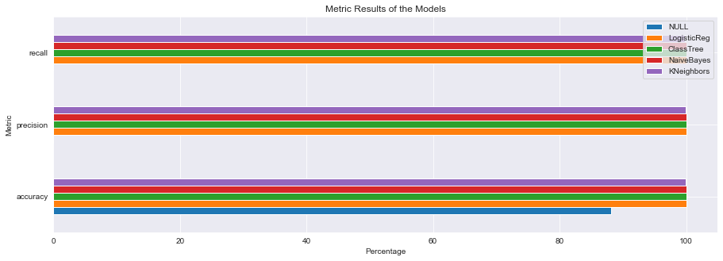

```python
# Plotting the metrics as a visualization
fig, ax = plt.subplots(figsize=(15,5))
metrics.plot(kind='barh', ax=ax)
ax.set_xlabel('Percentage')
ax.set_ylabel('Metric')
ax.set_title('Metric Results of the Models')

# Saving as a picture
plt.savefig('metrics/plot_m1.2_metrics_bar.png', dpi=300);
```

**Conclusion:** Looking at the "recall" shows that all models have approximately the same value. Only the NULL model shows a value of zero. The KNeighbors model has a percentage value of just under 100 percent.

The models with the best values are:

- **Lostic Regression**
- **Decision Tree**
- **Nave-Bayes**

## Classification Threshold: Modifying the classification threshold

Table of Content

Adjusting the values of "recall" and "precission" by modifying the classification threshold to see the relationship between these metrics with the function "precision_recall_curve"

- Passing real values: y-true
- Passing the predicted values: probas_pred

```python
# Defining the threshold of "recall" and "precission" of "NBC" and "KNN"

# NBC
NBC_proba = NBC.predict_proba(X_test)[:,1]
precision_nb, recall_nb, thresholds_nb = precision_recall_curve(y_true=y_test, probas_pred=NBC_proba)

# KNN
KNN_proba = KNN.predict_proba(X_test)[:,1]
precision_kn, recall_kn, thresholds_kn = precision_recall_curve(y_true=y_test, probas_pred=KNN_proba)
```

## Classification Threshold: Visualization of the recall/precision correlation of "NaiveBase" and "KNeighbors" models

Table of Content

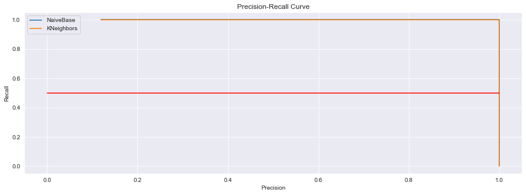

```python
# Visualization of the recall/precision correlation of "NBC"  and "KNN" models
fig, ax = plt.subplots(figsize=(15,5))
ax.plot(precision_nb, recall_nb, label='NaiveBase')
ax.plot(precision_kn, recall_kn, label='KNeighbors')
ax.set_xlabel('Precision')
ax.set_ylabel('Recall')
ax.hlines(y=0.5, xmin=0, xmax=1, color='red')
ax.set_title('Precision-Recall Curve')
ax.legend()

# Saving as a picture
plt.savefig('metrics/plot_m2_precision_recall_curve.png', dpi=300);
```

**Conclusion:** The visualization of the recall/precision correlation of "NaiveBase" and "KNeighbors" models depicts that both models have the best recall-score and precision score.

## Classification Threshold: Visualization of the recall, precision/threshold correlation of the "KNeighbors" model

Table of Content

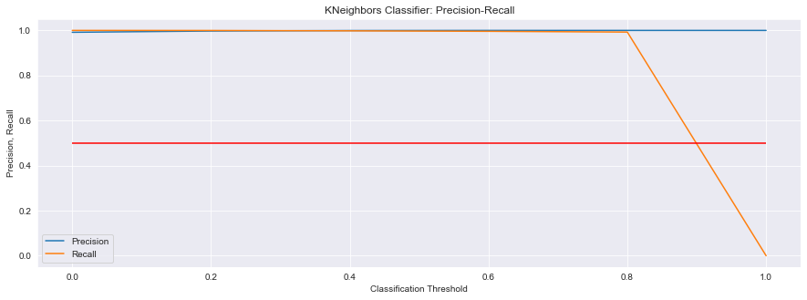

```python
# Visualization of the recall, precision/threshold correlation of the "KNN" model
fig, ax = plt.subplots(figsize=(15,5))
ax.plot(thresholds_kn, precision_kn[1:], label='Precision')
ax.plot(thresholds_kn, recall_kn[1:], label='Recall')
ax.set_xlabel('Classification Threshold')
ax.set_ylabel('Precision, Recall')
ax.hlines(y=0.5, xmin=0, xmax=1, color='red')
ax.set_title('KNeighbors Classifier: Precision-Recall')
ax.legend()

# Saving as a picture
plt.savefig('metrics/plot_m3_KNeighborsC_precision_recall.png', dpi=300);
```

## Classification Threshold: Adjusting "KNeigbhors" classifier with a threshold value of 0.95

Table of Content

This is an example which shows how to set the classification threshold to another value.

```python
# Creating the proba predictions
y_pred_proba = KNN.predict_proba(X_test)[:,1]

# Setting the classification threshold to "0.95"
y_pred_test = (y_pred_proba >= 0.95).astype('int')

# Printing 'recall' ans 'precision'
print('Precision: ', 100*precision_score(y_pred=y_pred_test, y_true=y_test))
print('Recall: ', 100*recall_score(y_pred=y_pred_test, y_true=y_test))

# Using the function: f_CMatrix
CM = confusion_matrix(y_pred=y_pred_test, y_true=y_test)
f_CMatrix(CM)
```

```
Precision:  100.0
Recall:  99.26026383923067
```

| PREDICTION TRUE | event_offer_completed | offer_type_bogo | TOTAL |
| --- | --- | --- | --- |
| event_offer_completed | 120159 | 0 | 120159 |
| offer_type_bogo | 120 | 16102 | 16222 |
| TOTAL | 120279 | 16102 | 136381 |

**Conclusion:**

- The confusion matrix depicts, that the adjusting of the classifier threshold to a value of *0.95* increases the precision-score.
- The recall-score decreases while adjusting the classifier threshold to a value of *0.95*.

# 5. Section 4: Results

Table of Content

## 5. A. Model Evaluation and Validation

Table of Content

For this project four different models are used to predict the relevant data. The NULL model is a benchmark comparison model to compare how good the final model has to perform. The NULL model is the simplest model within this analysis.

- Model: NULL
- Model A: Logistic Regression Classifier
- Model B: Decision Trees Classifier
- Model C: Naive Bayes Classifier
- Model D: KNeighbors Classifier

The following summary of the results shows that almost every model gives a very good prediction value and can be used for making predictions. The NULL model depicts even a lower accuracy as the other four models.

**Model: NULL**

**Model A: Logistic Regression Classifier**

**Model B: Decision Trees Classifier**

**Model C: Naive Bayes Classifier**

**Model D: KNeighbors Classifier**

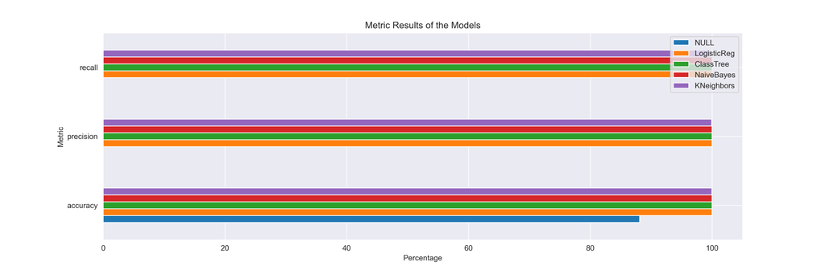

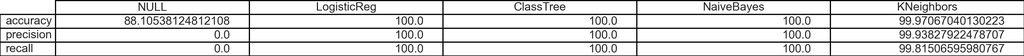

The above table depicts the following scores of the different models.

- the **accuracy score**,
- the **precision score** and
- the **recall score**

The models with the highest and equal values are (*accuracy* | *prescision* | *recall*):

- **Logistic Regression Classifier**  
  (a *100%* | p *100%* | r *100%*) → **Overfitting issue**
- **Decision Trees Classifier**  
  (a *100%* | p *100%* | r *100%*) → **Overfitting issue**
- **Naive Bayes Classifier**  
  (a *100%* | p *100%* | r *100%*) → **Overfitting issue**

These models have different results

- **Model: NULL**  
  (a *88.11%* | p *0%* | r *0%*)
- **Model D: KNeighbors Classifier**  
  (a *99.97%* | p *99.94%* | r *99.82%*)

It is recommended to choose a model which is not "too perfect" in accuracy due to the reason of an overfitting problem. Therefore the model of choice in this case is:

- **Model D: KNeighbors Classifier**

Still the scores of all models are very high. Which should always be questioned. One root cause could be a real overfitting issue of the model.

## 5. B. Justification

Table of Content

Overfitting means that a model is processing the training data too well. It will happen, when a statistical model fits exactly against the training data.

The reasons for the possible overfitting issue here could be:

> - The model learns the detail in the training data to the extent. This can negatively impact the performance of the model on new data.
> - Nonparametric (decision trees) and nonlinear models with more flexibility when learning a target can cause overfitting more often.

# 6. Section 5: Conclusion

Table of Content

## 6. A. Reflection

Table of Content

This project should display how to analyze the Starbucks datasets to finally build a predicting model. A model to predict if a customer will complete an offer based on the offer type *bogo*.

The most time consuming part of this project was the data wrangling part. Especially the `transcript.json` data frame had some tricky parts to clean and tidy up.

Also the data preprocessing part for the machine learning model was also very extensive. At one point or another one could have changed other parameters, which in retrospect seemed much too extensive as well.

In the end it was a very interesting data analysis that yielded the following insights.

### Observation

Question 1: How is the distribution of the variable "age"?

> **Conclusion:**
> 1. **Range of age:** The youngest customers are *18* and the oldest customers are *118*.
> 2. **Median of age:** The median of the age distribution is *57*.
> 3. **Mean of age:** The mean of the age distribution is approximately *61*.
> 4. **Outliers:** The counts of customer ages of the value *118* are outliers and.

Question 2: How is the distribution of the variable "gender"?

Question 3: How is the distribution of the variable "income"?

> **Conclusion:**
> 1. **Distribution:** The distribution of the variable "income" is *right-skewed* (positive skewness).
> 2. **Cluster:** There are *4* income clusters existing:

>    > **Cluster 1**: In a range between *30,000* and *50,000* USD.  
>    > **Cluster 2**: In a range between *50,000* and *75,000* USD.  
>    > **Cluster 3**: In a range between *75,000* and *100,000* USD.  
>    > **Cluster 4**: In a range between *100,000* and *120,000* USD.

Question 4: How is the distribution of the variable "gender" correlated to the age clusters?

**Conclusion:**

> 1. **Major Customer Group:** The distribution of the age clusters of customer genders depicts that adult males are the major customer group existing in the data.
> 2. **Second Biggest Customer Group:** Adult females are the second biggest customer group existing in the data.
> 3. **Third Biggest Customer Group:** The third biggest customer group existing in the data are senior males and females.

Question 5: How is the distribution of the variable "gender" correlated to the income clusters?

> **Conclusion:**
> 1. **Major Customer Group:** The distribution of the income clusters of customer genders depicts that adult males are the major customer group earning an avarage income.
> 2. **Second Biggest Customer Group:** Adult males are the second biggest customer group earning an low income.
> 3. **Third Biggest Customer Group:** Adult females are the third biggest customer group earning an average income followed by females which have a high wage earning.

Question 6: How is the distribution of the variable "age" correlated to the offer types?

> **Conclusion:**
> 1. **Major Customer Group:** The distribution of the offer types of customer age depicts that adults are the major customer group receiving the "bogo" and the "discount" offer type.
> 2. **Second Biggest Customer Group:** Seniors are the second biggest customer group receiving the "bogo" and the "discount" offer type.
> 3. **Third Biggest Customer Group:** Adults are the third biggest customer group receiving the "informational" offer type.

Question 7: How is the distribution of the variable "gender" correlated to the offer types?

> **Conclusion:**
> 1. **Major Customer Group:** The distribution of the offer types of customer genders depicts that males are the major customer group receiving the "bogo" and the "discount" offer type.
> 2. **Second Biggest Customer Group:** Females are the second biggest customer group receiving the "bogo" and the "discount" offer type.
> 3. **Third Biggest Customer Group:** Males are the third biggest customer group receiving the "informational" offer type.

Question 8: How is the distribution of the variable "gender" correlated to the events?

> **Conclusion:**
> 1. **Major Customer Group:** The distribution of the events of customer genders depicts that males are the major customer group doing a "transaction" and a "offer completed".
> 2. **Second Biggest Customer Group:** Females are the second biggest customer group doing a "transaction" and a "offer completed".
> 3. **Third Biggest Customer Group:** Males are the third biggest customer group "receiving" and "viewing" an offer.
> 4. **Major Customer Group:** The distribution of the events of customer genders depicts that males are the major customer group doing a "transaction" and a "offer completed".
> 5. **Insight:** The raltive distribution of the events considering "Female" and "Male" customer genders depicts that both genders have the same percentage share of *57,4%*

Question 9: How is the distribution of the variable "age" correlated to the events?

> **Conclusion:**
> 1. **Major Customer Group:** The distribution of the events of customer age depicts that adults are the major customer group doing a "transaction" and a "offer completed".
> 2. **Second Biggest Customer Group:** Seniors are the second biggest customer group doing a "transaction" and a "offer completed".
> 3. **Third Biggest Customer Group:** Adults are the third biggest customer group "receiving" and "viewing" an offer.
> 4. **Insight:** The raltive distribution of the events considering "Seniors" and "Adults" age clusters depicts that both age clusters have an almost equal percentage share of around *55%*

## 6. B. Improvement

Table of Content

Suggested improvements for another project are listed below.

> - Trying to include non-influenced/invalid models
>   > - **Decision tree:** A solution could be to prune the tree after it has learned in order to remove some of the detail it has picked up.
> - **KNeighborsClassifier model:** This model gives a really high score, too. Trying to improve such a model will cause overfitting.
> - Classification Threshold: Adjusting "KNeigbhors" classifier with a threshold value of 0.95

**Avoiding overfitting by**

> - **Stopping:** Pausing the training before the model starts learning the noise within the model.
> - **More training data:** Using a bigger training set to include more data can increase the accuracy of the model..
> - **Feature selection:** Identifying the most important features by feature selection and then eliminating the ones which are not necessary.
> - **Regularization:** If the features to remove from our model are not known, regularization methods can be used. It blocks the input parameters with the larger coefficients. This limits the amount of variance.
> - **Ensemble methods:** Identifying the most popular result by ensemble learning methods (e.g. decision tree) can be used based on their predictions.

### Suggestion: Tool for making individual predictions

Based on the KNeighbor Classifier the function below can be developed in another project task to predict if a new user will complete the offer, based on new data.

```python
# Function: Defining function to create a prediction tool for a new customer input based on new data.
# (Source of code parts: packtpub.com)
def F_prediction_new_cust_KNN(new_data):
    '''
    INPUT:
    new_data - Confusion matrix input values.

    OUTPUT:
    Statement ""Will complete."
    Statement ""Will NOT complete."

    Description:
    A prediction tool for a new customer input based on new data.
    '''
    data = new_data.values.reshape(1, -1)
    data = robust_scaler.transform(data)
    prob = KNN.predict_proba(data)[0][1]
    print(data)
    print(prob)
    if prob >= 0.95:
        return "Will complete."
    else:
        return "Will NOT complete."
```

# 7. References

Table of Content

[Data Source Picture 1](https://unsplash.com/photos/NlGjqcPACUw) (Date Compiled: 11 August, 2022)

[Data Source Picture 2](https://unsplash.com/photos/dThk3tBIp4Q) (Date Compiled: 11 August, 2022)

[Data Source Age Categories](https://www.statcan.gc.ca/en/concepts/definitions/age2) (Date Compiled: 16 August, 2022)

[Data Source ML Model](https://www.youtube.com/watch?v=zUqa6KcwRhs&ab_channel=PacktVideo) (Date Compiled: 28 August, 2022)

[Data Source Overfitting](https://machinelearningmastery.com/overfitting-and-underfitting-with-machine-learning-algorithms/#:~:text=Overfitting%20refers%20to%20a%20model,the%20model%20on%20new%20data) (Date Compiled: 29 August, 2022)

[Data Source Overfitting](https://www.ibm.com/cloud/learn/overfitting) (Date Compiled: 29 August, 2022)